# Introduction to Computer Vision: Plant Seedlings Classification

## Problem Statement

### Context

In recent times, the field of agriculture has been in urgent need of modernizing, since the amount of manual work people need to put in to check if plants are growing correctly is still highly extensive. Despite several advances in agricultural technology, people working in the agricultural industry still need to have the ability to sort and recognize different plants and weeds, which takes a lot of time and effort in the long term. The potential is ripe for this trillion-dollar industry to be greatly impacted by technological innovations that cut down on the requirement for manual labor, and this is where Artificial Intelligence can actually benefit the workers in this field, as **the time and energy required to identify plant seedlings will be greatly shortened by the use of AI and Deep Learning.** The ability to do so far more efficiently and even more effectively than experienced manual labor, could lead to better crop yields, the freeing up of human inolvement for higher-order agricultural decision making, and in the long term will result in more sustainable environmental practices in agriculture as well.

### Objective

The aim of this project is to Build a Convolutional Neural Network to classify plant seedlings into their respective categories.

### Data Dictionary

The Aarhus University Signal Processing group, in collaboration with the University of Southern Denmark, has recently released a dataset containing **images of unique plants belonging to 12 different species.**

- The dataset can be download from Olympus.
- The data file names are:
  - images.npy
  - Labels.csv
- Due to the large volume of data, the images were converted to the images.npy file and the labels are also put into Labels.csv, so that you can work on the data/project seamlessly without having to worry about the high data volume.
- The goal of the project is to create a classifier capable of determining a plant's species from an image.

**List of Species**

- Black-grass
- Charlock
- Cleavers
- Common Chickweed
- Common Wheat
- Fat Hen
- Loose Silky-bent
- Maize
- Scentless Mayweed
- Shepherds Purse
- Small-flowered Cranesbill
- Sugar beet

### **Note: Please use GPU runtime on Google Colab to execute the code faster.**

## Importing necessary libraries

```python
# Installing the libraries with the specified version.
# uncomment and run the following line if Google Colab is being used
# !pip install tensorflow==2.15.0 scikit-learn==1.2.2 seaborn==0.13.1 matplotlib==3.7.1 numpy==1.25.2 pandas==1.5.3 opencv-python==4.8.0.76 -q --user
```

```python
# Installing the libraries with the specified version.
# uncomment and run the following lines if Jupyter Notebook is being used
#!pip install tensorflow==2.13.0 scikit-learn==1.2.2 seaborn==0.11.1 matplotlib==3.3.4 numpy==1.24.3 pandas==1.5.2 opencv-python==4.8.0.76 -q --user
```

**Note**: *After running the above cell, kindly restart the notebook kernel and run all cells sequentially from the start again.*

```python
import os
import numpy as np                                                                               # Importing numpy for Matrix Operations
import pandas as pd                                                                              # Importing pandas to read CSV files
import matplotlib.pyplot as plt                                                                  # Importting matplotlib for Plotting and visualizing images
import math                                                                                      # Importing math module to perform mathematical operations
import cv2                                                                                       # Importing openCV for image processing
import seaborn as sns                                                                            # Importing seaborn to plot graphs


# Tensorflow modules
import tensorflow as tf
from tensorflow.keras.preprocessing.image import ImageDataGenerator                              # Importing the ImageDataGenerator for data augmentation
from tensorflow.keras.models import Sequential                                                   # Importing the sequential module to define a sequential model
from tensorflow.keras.layers import Dense,Dropout,Flatten,Conv2D,MaxPooling2D,BatchNormalization # Defining all the layers to build our CNN Model
from tensorflow.keras.optimizers import Adam,SGD                                                 # Importing the optimizers which can be used in our model
from sklearn import preprocessing
from sklearn.metrics import classification_report                                                # Importing the preprocessing module to preprocess the data
from sklearn.model_selection import train_test_split                                             # Importing train_test_split function to split the data into train and test
from sklearn.metrics import confusion_matrix                                                     # Importing confusion_matrix to plot the confusion matrix
from sklearn.preprocessing import LabelBinarizer
# Display images using OpenCV
from google.colab.patches import cv2_imshow                                                      # Importing cv2_imshow from google.patches to display images
from tensorflow.keras import backend
from keras.callbacks import ReduceLROnPlateau
import random
# Ignore warnings
import warnings
warnings.filterwarnings('ignore')
```

## Loading the dataset

```python
# Uncomment and run the below code if you are using google colab
from google.colab import drive
drive.mount('/content/drive')
```

```python
# Load the image file of dataset
images = np.load('/content/drive/MyDrive/Python Course/images.npy')

# Load the labels file of dataset
labels = pd.read_csv('/content/drive/MyDrive/Python Course/Labels.csv')
```

## Data Overview

### Understand the shape of the dataset

```python
print(images.shape)
print(labels.shape)
```

```
(4750, 128, 128, 3)
(4750, 1)
```

- There are 4750 images with 128 by 128 pixels and 3 channels.

## Exploratory Data Analysis

- EDA is an important part of any project involving data.
- It is important to investigate and understand the data better before building a model with it.
- A few questions have been mentioned below which will help you understand the data better.
- A thorough analysis of the data, in addition to the questions mentioned below, should be done.
1. How are these different category plant images different from each other?
2. Is the dataset provided an imbalance? (Check with using bar plots)

### Check if the images are in RGB or BRG format

- Plot images using OpenCV and matplotlib

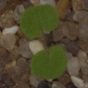

```python
cv2_imshow(images[253])
```

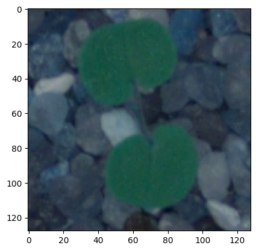

```python
plt.imshow(images[253])
```

- We can observe that the images are being shown in different colors when plotted with openCV and matplotlib as OpenCV reads images in BGR format and this shows that the given numpy arrays were generated from the original images using OpenCV.
- The pictures appear more normal in the BGR format, so they are in BGR format. SInce a lot of libraries and transfer learning models are standardized using RGB, we will be reformating to RGB as we proceed.

### Plotting random images from each of the class

```python
def plot_images(images,labels):
  num_classes=10                                                                  # Number of Classes
  categories=np.unique(labels)
  keys=dict(labels['Label'])                                                      # Obtaing the unique classes from y_train
  rows = 3                                                                        # Defining number of rows=3
  cols = 4                                                                        # Defining number of columns=4
  fig = plt.figure(figsize=(10, 8))                                               # Defining the figure size to 10x8
  for i in range(cols):
      for j in range(rows):
          random_index = np.random.randint(0, len(labels))                        # Generating random indices from the data and plotting the images
          ax = fig.add_subplot(rows, cols, i * rows + j + 1)                      # Adding subplots with 3 rows and 4 columns
          ax.imshow(images[random_index, :])                                      # Plotting the image
          ax.set_title(keys[random_index])
  plt.show()
```

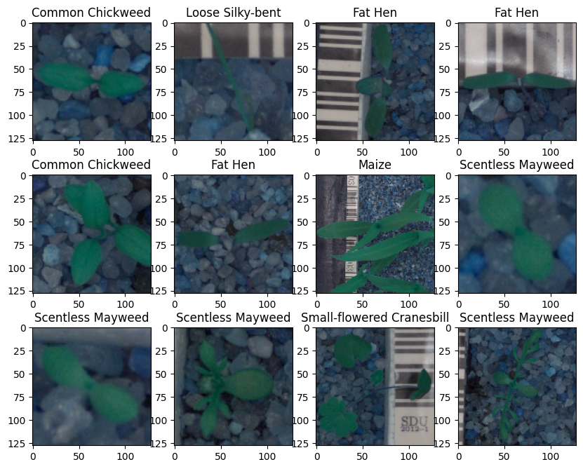

```python
plot_images(images,labels)
```

### Checking the distribution of the target variable

[output not shown]

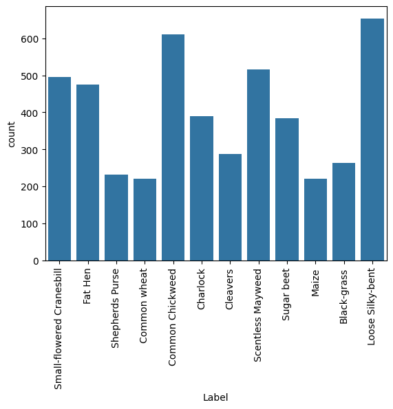

```python
sns.countplot(x=labels['Label'])
plt.xticks(rotation='vertical')
```

- We can notice that there is some imbalance in the data. Loose Silky-bent category has the highest number of images at over 600 images, Common Chickweed has just about 600 images, Small-flowered Cranesbill, Fat Hen, Charlock and Sugar beet have between 350 to just above 500 images, and the rest (Shepherds Purse, Common wheat, Cleavers, Maize and Black-grass) each have less than 300 images.
- We will address this imbalance later using Data Augmentation.

## Data Pre-Processing

### Converting the BGR images to RGB images.

```python
# Converting the images from BGR to RGB using cvtColor function of OpenCV
for i in range(len(images)):
  images[i] = cv2.cvtColor(images[i], cv2.COLOR_BGR2RGB)
```

### Resizing images

As the size of the images is large, it may be computationally expensive to train on these larger images; therefore, it is preferable to reduce the image size from 128 to 64.

```python
images_decreased=[]
height = 64
width =  64
dimensions = (width, height)
for i in range(len(images)):
  images_decreased.append( cv2.resize(images[i], dimensions, interpolation=cv2.INTER_LINEAR))
```

**Image before resizing**

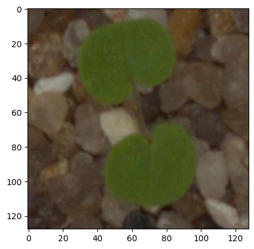

```python
plt.imshow(images[253])
```

**Image after resizing**

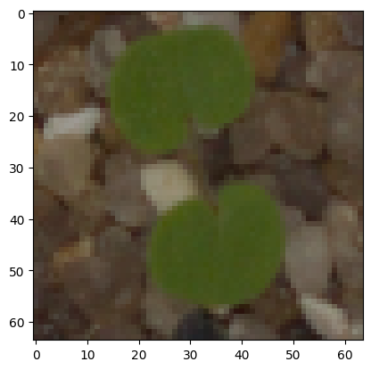

```python
plt.imshow(images_decreased[253])
```

### Data Preparation for Modeling

- Before you proceed to build a model, you need to split the data into train, test, and validation to be able to evaluate the model that you build on the train data
- You'll have to encode categorical features and scale the pixel values.
- You will build a model using the train data and then check its performance

**Split the dataset**

- As we have less images in our dataset, we will only use 10% of our data for testing, 10% of our data for validation and 80% of our data for training.
- We are using the train_test_split() function from scikit-learn. Here, we split the dataset into three parts, train,test and validation.

```python
X_temp, X_test, y_temp, y_test = train_test_split(np.array(images_decreased), labels , test_size=0.1, random_state=42,stratify=labels)
X_train, X_val, y_train, y_val = train_test_split(X_temp, y_temp, test_size=0.1, random_state=42,stratify=y_temp)
```

```python
print(X_train.shape,y_train.shape)
print(X_val.shape,y_val.shape)
print(X_test.shape,y_test.shape)
```

```
(3847, 64, 64, 3) (3847, 1)
(428, 64, 64, 3) (428, 1)
(475, 64, 64, 3) (475, 1)
```

**Make the data compatible:**

- Convert labels from names to one hot vectors
- Normalize the values

### Encode the target labels

```python
# Convert labels from names to one hot vectors.
# We have already used encoding methods like onehotencoder and labelencoder earlier so now we will be using a new encoding method called labelBinarizer.
# Labelbinarizer works similar to onehotencoder

enc = LabelBinarizer()
y_train_encoded = enc.fit_transform(y_train)
y_val_encoded=enc.transform(y_val)
y_test_encoded=enc.transform(y_test)
```

```python
y_train_encoded.shape,y_val_encoded.shape,y_test_encoded.shape
```

```
((3847, 12), (428, 12), (475, 12))
```

### Data Normalization

Since the **image pixel values range from 0-255**, our method of normalization here will be **scaling** - we shall **divide all the pixel values by 255 to standardize the images to have values between 0-1.**

```python
X_train_normalized = X_train.astype('float32')/255.0
X_val_normalized = X_val.astype('float32')/255.0
X_test_normalized = X_test.astype('float32')/255.0
```

## Model Building

### Initial CNN Model

```python
# Clearing backend
backend.clear_session()
```

```python
# Fixing the seed for random number generators
np.random.seed(42)
random.seed(42)
tf.random.set_seed(42)
```

**Now, let's build a CNN Model with the following 2 main parts:**

1. The Feature Extraction layers which are comprised of convolutional and pooling layers.
2. The Fully Connected classification layers for prediction.

```python
# Intializing a sequential model
model1 = Sequential()

# Add the first conv layer with 64 filters and kernel size 3x3 , padding 'same' provides the output size same as the input size
# Input_shape denotes input image dimension of images
model1.add(Conv2D(64, (3, 3), activation='relu', padding="same", input_shape=(64, 64, 3)))
# Add the max pooling to reduce the size of output of first conv layer
model1.add(MaxPooling2D((2, 2), padding = 'same'))

# Create convolution and max-pooling layers activation = relu
model1.add(Conv2D(32, (3, 3), activation='relu', padding="same"))
model1.add(MaxPooling2D((2, 2), padding = 'same'))

# Flatten the output of the conv layer after max pooling to make it ready for creating dense connections
model1.add(Flatten())

# Add a fully connected dense layer with 16 neurons
model1.add(Dense(16, activation='relu'))
model1.add(Dropout(0.3))

# Add the output layer with 12 neurons and activation functions as softmax since this is a multi-class classification problem
model1.add(Dense(12, activation='softmax'))

# Use the Adam Optimizer
opt=Adam()

# Compile the model using suitable metric for loss fucntion
model1.compile(optimizer=opt, loss='categorical_crossentropy', metrics=['accuracy'])

# Generate the summary of the model
model1.summary()
```

```
Model: "sequential"
```

```
┏━━━━━━━━━━━━━━━━━━━━━━━━━━━━━━━━━━━━━━┳━━━━━━━━━━━━━━━━━━━━━━━━━━━━━┳━━━━━━━━━━━━━━━━━┓
┃ Layer (type)                         ┃ Output Shape                ┃         Param # ┃
┡━━━━━━━━━━━━━━━━━━━━━━━━━━━━━━━━━━━━━━╇━━━━━━━━━━━━━━━━━━━━━━━━━━━━━╇━━━━━━━━━━━━━━━━━┩
│ conv2d (Conv2D)                      │ (None, 64, 64, 64)          │           1,792 │
├──────────────────────────────────────┼─────────────────────────────┼─────────────────┤
│ max_pooling2d (MaxPooling2D)         │ (None, 32, 32, 64)          │               0 │
├──────────────────────────────────────┼─────────────────────────────┼─────────────────┤
│ conv2d_1 (Conv2D)                    │ (None, 32, 32, 32)          │          18,464 │
├──────────────────────────────────────┼─────────────────────────────┼─────────────────┤
│ max_pooling2d_1 (MaxPooling2D)       │ (None, 16, 16, 32)          │               0 │
├──────────────────────────────────────┼─────────────────────────────┼─────────────────┤
│ flatten (Flatten)                    │ (None, 8192)                │               0 │
├──────────────────────────────────────┼─────────────────────────────┼─────────────────┤
│ dense (Dense)                        │ (None, 16)                  │         131,088 │
├──────────────────────────────────────┼─────────────────────────────┼─────────────────┤
│ dropout (Dropout)                    │ (None, 16)                  │               0 │
├──────────────────────────────────────┼─────────────────────────────┼─────────────────┤
│ dense_1 (Dense)                      │ (None, 12)                  │             204 │
└──────────────────────────────────────┴─────────────────────────────┴─────────────────┘
```

```
 Total params: 151,548 (591.98 KB)
```

```
 Trainable params: 151,548 (591.98 KB)
```

```
 Non-trainable params: 0 (0.00 B)
```

- There are 151,548 trainable parameters for this model.

**Fitting the model on the train data**

**Model1 - Run 1**

- Epochs=25
- Batch_Size=64

```python
# Fit the model on train and also using the validation data for validation
history_1 = model1.fit(
            X_train_normalized, y_train_encoded,
            epochs=25,
            validation_data=(X_val_normalized,y_val_encoded),
            batch_size=64,
            verbose=2
)
```

```
61/61 - 39s - 641ms/step - accuracy: 0.1055 - loss: 2.4539 - val_accuracy: 0.1402 - val_loss: 2.4279
61/61 - 43s - 703ms/step - accuracy: 0.2035 - loss: 2.3582 - val_accuracy: 0.3364 - val_loss: 2.1820
61/61 - 38s - 626ms/step - accuracy: 0.2854 - loss: 2.1404 - val_accuracy: 0.3925 - val_loss: 1.9708
61/61 - 41s - 674ms/step - accuracy: 0.3052 - loss: 1.9974 - val_accuracy: 0.4136 - val_loss: 1.8017
61/61 - 40s - 660ms/step - accuracy: 0.3119 - loss: 1.9159 - val_accuracy: 0.4299 - val_loss: 1.7903
61/61 - 46s - 761ms/step - accuracy: 0.3106 - loss: 1.8802 - val_accuracy: 0.4626 - val_loss: 1.7034
61/61 - 39s - 641ms/step - accuracy: 0.3317 - loss: 1.8173 - val_accuracy: 0.4696 - val_loss: 1.6167
61/61 - 36s - 594ms/step - accuracy: 0.3400 - loss: 1.7681 - val_accuracy: 0.4813 - val_loss: 1.5653
61/61 - 43s - 705ms/step - accuracy: 0.3587 - loss: 1.7182 - val_accuracy: 0.4977 - val_loss: 1.5454
61/61 - 39s - 632ms/step - accuracy: 0.3663 - loss: 1.7025 - val_accuracy: 0.4907 - val_loss: 1.5326
61/61 - 41s - 673ms/step - accuracy: 0.3787 - loss: 1.6919 - val_accuracy: 0.5117 - val_loss: 1.4217
61/61 - 44s - 716ms/step - accuracy: 0.3743 - loss: 1.6763 - val_accuracy: 0.5023 - val_loss: 1.4520
61/61 - 40s - 661ms/step - accuracy: 0.3808 - loss: 1.6486 - val_accuracy: 0.4930 - val_loss: 1.4416
61/61 - 39s - 637ms/step - accuracy: 0.3907 - loss: 1.6115 - val_accuracy: 0.5117 - val_loss: 1.4090
61/61 - 39s - 634ms/step - accuracy: 0.3930 - loss: 1.6017 - val_accuracy: 0.5047 - val_loss: 1.4377
61/61 - 37s - 606ms/step - accuracy: 0.4180 - loss: 1.5915 - val_accuracy: 0.5467 - val_loss: 1.3513
61/61 - 40s - 661ms/step - accuracy: 0.4040 - loss: 1.5706 - val_accuracy: 0.5117 - val_loss: 1.3694
61/61 - 43s - 701ms/step - accuracy: 0.4182 - loss: 1.5565 - val_accuracy: 0.5444 - val_loss: 1.3660
61/61 - 39s - 633ms/step - accuracy: 0.4211 - loss: 1.5162 - val_accuracy: 0.5444 - val_loss: 1.3235
61/61 - 43s - 703ms/step - accuracy: 0.4388 - loss: 1.4904 - val_accuracy: 0.5397 - val_loss: 1.3202
61/61 - 45s - 733ms/step - accuracy: 0.4302 - loss: 1.4954 - val_accuracy: 0.5491 - val_loss: 1.3318
61/61 - 74s - 1s/step - accuracy: 0.4307 - loss: 1.4951 - val_accuracy: 0.5631 - val_loss: 1.2483
61/61 - 37s - 607ms/step - accuracy: 0.4424 - loss: 1.4642 - val_accuracy: 0.5794 - val_loss: 1.2534
61/61 - 40s - 658ms/step - accuracy: 0.4299 - loss: 1.4838 - val_accuracy: 0.5841 - val_loss: 1.2328
61/61 - 38s - 616ms/step - accuracy: 0.4492 - loss: 1.4528 - val_accuracy: 0.5818 - val_loss: 1.2147
```

- Train accuracy is 45%; validation accuracy is 58%.

**Model1 - Run 2**

- Epochs=30
- Batch_Size=32

```python
# Clearing backend
backend.clear_session()
```

```python
# Fixing the seed for random number generators
np.random.seed(42)
random.seed(42)
tf.random.set_seed(42)
```

```python
# Fit the model on train and also using the validation data for validation
history_1 = model1.fit(
            X_train_normalized, y_train_encoded,
            epochs=30,
            validation_data=(X_val_normalized,y_val_encoded),
            batch_size=32,
            verbose=2
)
```

```
121/121 - 35s - 293ms/step - accuracy: 0.1167 - loss: 2.4565 - val_accuracy: 0.1379 - val_loss: 2.4344
121/121 - 34s - 283ms/step - accuracy: 0.1489 - loss: 2.4162 - val_accuracy: 0.1986 - val_loss: 2.3528
121/121 - 39s - 321ms/step - accuracy: 0.2308 - loss: 2.2466 - val_accuracy: 0.3084 - val_loss: 2.1182
121/121 - 32s - 264ms/step - accuracy: 0.2800 - loss: 2.1592 - val_accuracy: 0.3364 - val_loss: 2.0479
121/121 - 41s - 337ms/step - accuracy: 0.2950 - loss: 2.0711 - val_accuracy: 0.3715 - val_loss: 1.9111
121/121 - 42s - 343ms/step - accuracy: 0.2911 - loss: 1.9682 - val_accuracy: 0.3879 - val_loss: 1.7533
121/121 - 40s - 331ms/step - accuracy: 0.2976 - loss: 1.8836 - val_accuracy: 0.3972 - val_loss: 1.6618
121/121 - 42s - 347ms/step - accuracy: 0.3182 - loss: 1.8524 - val_accuracy: 0.4065 - val_loss: 1.6364
121/121 - 41s - 337ms/step - accuracy: 0.3351 - loss: 1.8014 - val_accuracy: 0.3995 - val_loss: 1.6133
121/121 - 43s - 356ms/step - accuracy: 0.3377 - loss: 1.7935 - val_accuracy: 0.3972 - val_loss: 1.6088
121/121 - 38s - 317ms/step - accuracy: 0.3431 - loss: 1.7782 - val_accuracy: 0.4486 - val_loss: 1.5603
121/121 - 41s - 335ms/step - accuracy: 0.3507 - loss: 1.7327 - val_accuracy: 0.4463 - val_loss: 1.5420
121/121 - 41s - 339ms/step - accuracy: 0.3462 - loss: 1.7301 - val_accuracy: 0.4579 - val_loss: 1.5465
121/121 - 32s - 264ms/step - accuracy: 0.3611 - loss: 1.7189 - val_accuracy: 0.4743 - val_loss: 1.5218
121/121 - 40s - 332ms/step - accuracy: 0.3657 - loss: 1.6848 - val_accuracy: 0.4556 - val_loss: 1.5063
121/121 - 30s - 250ms/step - accuracy: 0.3811 - loss: 1.6597 - val_accuracy: 0.4790 - val_loss: 1.4691
121/121 - 40s - 334ms/step - accuracy: 0.3943 - loss: 1.6304 - val_accuracy: 0.4766 - val_loss: 1.5000
121/121 - 32s - 266ms/step - accuracy: 0.3990 - loss: 1.6068 - val_accuracy: 0.4836 - val_loss: 1.4506
121/121 - 40s - 333ms/step - accuracy: 0.4190 - loss: 1.5651 - val_accuracy: 0.4766 - val_loss: 1.5299
121/121 - 41s - 342ms/step - accuracy: 0.4089 - loss: 1.5674 - val_accuracy: 0.5234 - val_loss: 1.5014
121/121 - 39s - 326ms/step - accuracy: 0.4229 - loss: 1.5443 - val_accuracy: 0.5140 - val_loss: 1.4902
121/121 - 30s - 251ms/step - accuracy: 0.4164 - loss: 1.5413 - val_accuracy: 0.5257 - val_loss: 1.4467
121/121 - 34s - 278ms/step - accuracy: 0.4299 - loss: 1.5365 - val_accuracy: 0.5140 - val_loss: 1.4943
121/121 - 39s - 326ms/step - accuracy: 0.4260 - loss: 1.5225 - val_accuracy: 0.5140 - val_loss: 1.4871
121/121 - 41s - 335ms/step - accuracy: 0.4429 - loss: 1.5019 - val_accuracy: 0.5304 - val_loss: 1.4269
121/121 - 41s - 338ms/step - accuracy: 0.4388 - loss: 1.5017 - val_accuracy: 0.5350 - val_loss: 1.4243
121/121 - 40s - 327ms/step - accuracy: 0.4463 - loss: 1.4802 - val_accuracy: 0.5491 - val_loss: 1.4194
121/121 - 41s - 340ms/step - accuracy: 0.4567 - loss: 1.4545 - val_accuracy: 0.5280 - val_loss: 1.4406
121/121 - 41s - 339ms/step - accuracy: 0.4580 - loss: 1.4485 - val_accuracy: 0.5234 - val_loss: 1.4169
121/121 - 32s - 263ms/step - accuracy: 0.4656 - loss: 1.4383 - val_accuracy: 0.5327 - val_loss: 1.4237
```

- Train accuracy is 46%; validation accuracy is 53%.

**Model1 - Run 3**

- Epochs=50
- Batch_Size=32

```python
# Clearing backend
backend.clear_session()
```

```python
# Fixing the seed for random number generators
np.random.seed(42)
random.seed(42)
tf.random.set_seed(42)
```

```python
# Fit the model on train and also using the validation data for validation
history_1 = model1.fit(
            X_train_normalized, y_train_encoded,
            epochs=50,
            validation_data=(X_val_normalized,y_val_encoded),
            batch_size=32,
            verbose=2
)
```

```
121/121 - 34s - 282ms/step - accuracy: 0.4713 - loss: 1.4271 - val_accuracy: 0.5724 - val_loss: 1.3938
121/121 - 39s - 324ms/step - accuracy: 0.4710 - loss: 1.4342 - val_accuracy: 0.5374 - val_loss: 1.4388
121/121 - 41s - 342ms/step - accuracy: 0.4713 - loss: 1.4193 - val_accuracy: 0.5397 - val_loss: 1.4555
121/121 - 32s - 264ms/step - accuracy: 0.4845 - loss: 1.4231 - val_accuracy: 0.5514 - val_loss: 1.3712
121/121 - 34s - 277ms/step - accuracy: 0.4900 - loss: 1.3696 - val_accuracy: 0.5444 - val_loss: 1.3999
121/121 - 40s - 327ms/step - accuracy: 0.5134 - loss: 1.3145 - val_accuracy: 0.5421 - val_loss: 1.3984
121/121 - 41s - 341ms/step - accuracy: 0.5168 - loss: 1.2998 - val_accuracy: 0.5631 - val_loss: 1.3381
121/121 - 41s - 338ms/step - accuracy: 0.5175 - loss: 1.2876 - val_accuracy: 0.5607 - val_loss: 1.3633
121/121 - 43s - 351ms/step - accuracy: 0.5214 - loss: 1.2680 - val_accuracy: 0.5607 - val_loss: 1.3607
121/121 - 39s - 321ms/step - accuracy: 0.5181 - loss: 1.2581 - val_accuracy: 0.5794 - val_loss: 1.3381
121/121 - 31s - 255ms/step - accuracy: 0.5329 - loss: 1.2416 - val_accuracy: 0.5584 - val_loss: 1.3378
121/121 - 43s - 357ms/step - accuracy: 0.5311 - loss: 1.2170 - val_accuracy: 0.5444 - val_loss: 1.3142
121/121 - 39s - 321ms/step - accuracy: 0.5342 - loss: 1.2106 - val_accuracy: 0.5654 - val_loss: 1.3201
121/121 - 41s - 338ms/step - accuracy: 0.5461 - loss: 1.1868 - val_accuracy: 0.5701 - val_loss: 1.3309
121/121 - 31s - 256ms/step - accuracy: 0.5376 - loss: 1.1916 - val_accuracy: 0.5888 - val_loss: 1.3119
121/121 - 41s - 339ms/step - accuracy: 0.5472 - loss: 1.1655 - val_accuracy: 0.5234 - val_loss: 1.3735
121/121 - 41s - 338ms/step - accuracy: 0.5612 - loss: 1.1541 - val_accuracy: 0.6028 - val_loss: 1.2901
121/121 - 33s - 277ms/step - accuracy: 0.5422 - loss: 1.1562 - val_accuracy: 0.5794 - val_loss: 1.3260
121/121 - 38s - 318ms/step - accuracy: 0.5604 - loss: 1.1312 - val_accuracy: 0.5981 - val_loss: 1.2836
121/121 - 41s - 340ms/step - accuracy: 0.5610 - loss: 1.1110 - val_accuracy: 0.5771 - val_loss: 1.4143
121/121 - 41s - 338ms/step - accuracy: 0.5633 - loss: 1.0927 - val_accuracy: 0.5818 - val_loss: 1.3521
121/121 - 41s - 340ms/step - accuracy: 0.5755 - loss: 1.0781 - val_accuracy: 0.5771 - val_loss: 1.3720
121/121 - 34s - 278ms/step - accuracy: 0.5799 - loss: 1.0703 - val_accuracy: 0.5818 - val_loss: 1.5004
121/121 - 38s - 317ms/step - accuracy: 0.5893 - loss: 1.0606 - val_accuracy: 0.5911 - val_loss: 1.2972
121/121 - 41s - 340ms/step - accuracy: 0.5973 - loss: 1.0192 - val_accuracy: 0.5981 - val_loss: 1.3675
121/121 - 41s - 338ms/step - accuracy: 0.5885 - loss: 1.0411 - val_accuracy: 0.5678 - val_loss: 1.5134
121/121 - 41s - 335ms/step - accuracy: 0.6023 - loss: 0.9955 - val_accuracy: 0.5794 - val_loss: 1.6371
121/121 - 42s - 349ms/step - accuracy: 0.5851 - loss: 1.0349 - val_accuracy: 0.6005 - val_loss: 1.4202
121/121 - 41s - 338ms/step - accuracy: 0.6085 - loss: 0.9775 - val_accuracy: 0.5771 - val_loss: 1.5611
121/121 - 40s - 331ms/step - accuracy: 0.6228 - loss: 0.9665 - val_accuracy: 0.5958 - val_loss: 1.5059
121/121 - 41s - 338ms/step - accuracy: 0.6184 - loss: 0.9633 - val_accuracy: 0.5794 - val_loss: 1.5726
121/121 - 41s - 338ms/step - accuracy: 0.6249 - loss: 0.9645 - val_accuracy: 0.6051 - val_loss: 1.3962
121/121 - 31s - 256ms/step - accuracy: 0.6382 - loss: 0.9118 - val_accuracy: 0.5911 - val_loss: 1.4681
121/121 - 43s - 357ms/step - accuracy: 0.6283 - loss: 0.9346 - val_accuracy: 0.5911 - val_loss: 1.4909
121/121 - 31s - 255ms/step - accuracy: 0.6259 - loss: 0.9339 - val_accuracy: 0.6075 - val_loss: 1.4684
121/121 - 30s - 251ms/step - accuracy: 0.6259 - loss: 0.9332 - val_accuracy: 0.6145 - val_loss: 1.4437
121/121 - 42s - 349ms/step - accuracy: 0.6317 - loss: 0.9083 - val_accuracy: 0.6145 - val_loss: 1.4218
121/121 - 31s - 254ms/step - accuracy: 0.6410 - loss: 0.8874 - val_accuracy: 0.5864 - val_loss: 1.4852
121/121 - 31s - 257ms/step - accuracy: 0.6579 - loss: 0.8652 - val_accuracy: 0.5818 - val_loss: 1.5677
121/121 - 44s - 366ms/step - accuracy: 0.6504 - loss: 0.8740 - val_accuracy: 0.6121 - val_loss: 1.5116
121/121 - 38s - 313ms/step - accuracy: 0.6558 - loss: 0.8659 - val_accuracy: 0.6028 - val_loss: 1.5781
121/121 - 41s - 336ms/step - accuracy: 0.6574 - loss: 0.8473 - val_accuracy: 0.6051 - val_loss: 1.5731
121/121 - 41s - 335ms/step - accuracy: 0.6545 - loss: 0.8500 - val_accuracy: 0.6355 - val_loss: 1.5609
121/121 - 42s - 344ms/step - accuracy: 0.6655 - loss: 0.8470 - val_accuracy: 0.6098 - val_loss: 1.5525
121/121 - 43s - 356ms/step - accuracy: 0.6564 - loss: 0.8607 - val_accuracy: 0.5981 - val_loss: 1.4325
121/121 - 39s - 322ms/step - accuracy: 0.6538 - loss: 0.8512 - val_accuracy: 0.6098 - val_loss: 1.5471
121/121 - 40s - 335ms/step - accuracy: 0.6483 - loss: 0.8592 - val_accuracy: 0.6238 - val_loss: 1.5612
121/121 - 41s - 338ms/step - accuracy: 0.6556 - loss: 0.8354 - val_accuracy: 0.6262 - val_loss: 1.5271
121/121 - 42s - 345ms/step - accuracy: 0.6595 - loss: 0.8332 - val_accuracy: 0.6262 - val_loss: 1.5155
121/121 - 42s - 348ms/step - accuracy: 0.6823 - loss: 0.8012 - val_accuracy: 0.6215 - val_loss: 1.5468
```

- Train accuracy is 68%; validation accuracy is 62%.

**Observations**

**Model Evaluation**

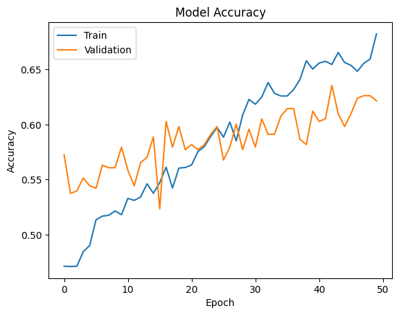

```python
plt.plot(history_1.history['accuracy'])
plt.plot(history_1.history['val_accuracy'])
plt.title('Model Accuracy')
plt.ylabel('Accuracy')
plt.xlabel('Epoch')
plt.legend(['Train', 'Validation'], loc='upper left')
plt.show()
```

**Evaluate the model on test data**

```python
accuracy = model1.evaluate(X_test_normalized, y_test_encoded, verbose=2)
```

```
15/15 - 1s - 52ms/step - accuracy: 0.6253 - loss: 1.8168
```

- Test accuracy is 63%

**Plotting the Confusion Matrix**

```python
# Here we would get the output as probablities for each category
y_pred=model1.predict(X_test_normalized)
```

```
15/15 ━━━━━━━━━━━━━━━━━━━━ 1s 57ms/step
```

```python
y_pred
```

```
array([[1.6655920e-28, 1.8302655e-20, 1.4108207e-30, ..., 3.1499814e-03,
        6.9069358e-18, 3.5425612e-07],
       [1.6548434e-24, 7.0674087e-06, 5.4684160e-03, ..., 6.6749976e-06,
        9.7856855e-01, 1.3093031e-06],
       [2.6476122e-18, 1.8482256e-01, 5.0541028e-02, ..., 1.3371421e-01,
        4.8941612e-01, 3.5396699e-02],
       ...,
       [1.0415484e-02, 1.1444494e-24, 7.3358812e-11, ..., 1.9531360e-22,
        3.4044496e-18, 8.0177372e-11],
       [1.6011682e-11, 1.2086531e-05, 1.0299438e-08, ..., 9.4326854e-02,
        9.3748395e-07, 2.6682200e-02],
       [2.3864948e-05, 3.5874833e-05, 1.3562822e-01, ..., 1.2426153e-04,
        4.7820729e-01, 2.0534698e-04]], dtype=float32)
```

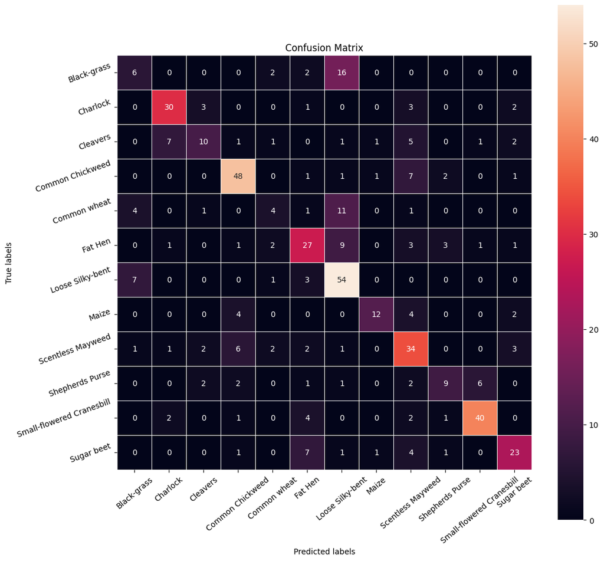

```python
# Obtaining the categorical values from y_test_encoded and y_pred
y_pred_arg=np.argmax(y_pred,axis=1)
y_test_arg=np.argmax(y_test_encoded,axis=1)

# Plotting the Confusion Matrix using confusion matrix() function which is also predefined in tensorflow module
confusion_matrix = tf.math.confusion_matrix(y_test_arg,y_pred_arg)
f, ax = plt.subplots(figsize=(12, 12))
sns.heatmap(
    confusion_matrix,
    annot=True,
    linewidths=.4,
    fmt="d",
    square=True,
    ax=ax
)
# Setting the labels to both the axes
ax.set_xlabel('Predicted labels');ax.set_ylabel('True labels');
ax.set_title('Confusion Matrix');
ax.xaxis.set_ticklabels(list(enc.classes_),rotation=40)
ax.yaxis.set_ticklabels(list(enc.classes_),rotation=20)
plt.show()
```

**Observations**

- We observe that while the test accuracy of the model at 63%, the classes are still quite a number of misclassifications due to incorrect predictions.
- For example, Black-grass was majorly classified as Loose Silky-bent.

**Plotting Classification Report**

```python
# Plotting the classification report
class_names=list(enc.classes_)
cr=classification_report(y_test_arg,y_pred_arg,target_names=class_names)
print(cr)
```

```
                           precision    recall  f1-score   support

              Black-grass       0.33      0.23      0.27        26
                 Charlock       0.73      0.77      0.75        39
                 Cleavers       0.56      0.34      0.43        29
         Common Chickweed       0.75      0.79      0.77        61
             Common wheat       0.33      0.18      0.24        22
                  Fat Hen       0.55      0.56      0.56        48
         Loose Silky-bent       0.57      0.83      0.68        65
                    Maize       0.80      0.55      0.65        22
        Scentless Mayweed       0.52      0.65      0.58        52
          Shepherds Purse       0.56      0.39      0.46        23
Small-flowered Cranesbill       0.83      0.80      0.82        50
               Sugar beet       0.68      0.61      0.64        38

                 accuracy                           0.63       475
                macro avg       0.60      0.56      0.57       475
             weighted avg       0.62      0.63      0.61       475
```

**Observations**

- Looking at the **Precision. Recall and f1-score**, Charlock, Common Chickweed and Small-flowered Cranesbill, maintained high scores across all parameters, while Black-grass and Common wheat had lower scores across all parameters.
- In comparison to the rest, we observe the Loose Silky-bent was classified at about 83% correctly, which was the most corectly classified category.

### Second CNN Model

- This second model is a little bit more complex with more layers than the previous one.

```python
# Clearing backend
backend.clear_session()
```

```python
# Fixing the seed for random number generators
np.random.seed(42)
random.seed(42)
tf.random.set_seed(42)
```

**Now, let's build a CNN Model with the following 2 main parts:**

1. The Feature Extraction layers which are comprised of convolutional and pooling layers.
2. The Fully Connected classification layers for prediction.

```python
# Intializing a sequential model
model2 = Sequential()

# Add the first conv layer with 128 filters and kernel size 3x3 , padding 'same' provides the output size same as the input size
# Input_shape denotes input image dimension of images
model2.add(Conv2D(128, (3, 3), activation='relu', padding="same", input_shape=(64, 64, 3)))
# Add the max pooling to reduce the size of output of first conv layer
model2.add(MaxPooling2D((2, 2), padding = 'same'))

# Create two similar convolution and max-pooling layers activation = relu
model2.add(Conv2D(64, (3, 3), activation='relu', padding="same"))
model2.add(MaxPooling2D((2, 2), padding = 'same'))

model2.add(Conv2D(32, (3, 3), activation='relu', padding="same"))
model2.add(MaxPooling2D((2, 2), padding = 'same'))

# Flatten the output of the conv layer after max pooling to make it ready for creating dense connections
model2.add(Flatten())

# Add a fully connected dense layer with 16 neurons
model2.add(Dense(16, activation='relu'))
model2.add(Dropout(0.3))

# Add the output layer with 12 neurons and activation functions as softmax since this is a multi-class classification problem
model2.add(Dense(12, activation='softmax'))

# Use the Adam Optimizer
opt=Adam()

# Compile the model using suitable metric for loss fucntion
model2.compile(optimizer=opt, loss='categorical_crossentropy', metrics=['accuracy'])

# Generate the summary of the model
model2.summary()
```

```
Model: "sequential"
```

```
┏━━━━━━━━━━━━━━━━━━━━━━━━━━━━━━━━━━━━━━┳━━━━━━━━━━━━━━━━━━━━━━━━━━━━━┳━━━━━━━━━━━━━━━━━┓
┃ Layer (type)                         ┃ Output Shape                ┃         Param # ┃
┡━━━━━━━━━━━━━━━━━━━━━━━━━━━━━━━━━━━━━━╇━━━━━━━━━━━━━━━━━━━━━━━━━━━━━╇━━━━━━━━━━━━━━━━━┩
│ conv2d (Conv2D)                      │ (None, 64, 64, 128)         │           3,584 │
├──────────────────────────────────────┼─────────────────────────────┼─────────────────┤
│ max_pooling2d (MaxPooling2D)         │ (None, 32, 32, 128)         │               0 │
├──────────────────────────────────────┼─────────────────────────────┼─────────────────┤
│ conv2d_1 (Conv2D)                    │ (None, 32, 32, 64)          │          73,792 │
├──────────────────────────────────────┼─────────────────────────────┼─────────────────┤
│ max_pooling2d_1 (MaxPooling2D)       │ (None, 16, 16, 64)          │               0 │
├──────────────────────────────────────┼─────────────────────────────┼─────────────────┤
│ conv2d_2 (Conv2D)                    │ (None, 16, 16, 32)          │          18,464 │
├──────────────────────────────────────┼─────────────────────────────┼─────────────────┤
│ max_pooling2d_2 (MaxPooling2D)       │ (None, 8, 8, 32)            │               0 │
├──────────────────────────────────────┼─────────────────────────────┼─────────────────┤
│ flatten (Flatten)                    │ (None, 2048)                │               0 │
├──────────────────────────────────────┼─────────────────────────────┼─────────────────┤
│ dense (Dense)                        │ (None, 16)                  │          32,784 │
├──────────────────────────────────────┼─────────────────────────────┼─────────────────┤
│ dropout (Dropout)                    │ (None, 16)                  │               0 │
├──────────────────────────────────────┼─────────────────────────────┼─────────────────┤
│ dense_1 (Dense)                      │ (None, 12)                  │             204 │
└──────────────────────────────────────┴─────────────────────────────┴─────────────────┘
```

```
 Total params: 128,828 (503.23 KB)
```

```
 Trainable params: 128,828 (503.23 KB)
```

```
 Non-trainable params: 0 (0.00 B)
```

**Fitting the model on the train data**

**Model2 - Run 1**

```python
# Fit the model on train and also using the validation data for validation
history_2 = model2.fit(
            X_train_normalized, y_train_encoded,
            epochs=50,
            validation_data=(X_val_normalized,y_val_encoded),
            batch_size=64,
            verbose=2
)
```

```
61/61 - 11s - 176ms/step - accuracy: 0.1100 - loss: 2.4738 - val_accuracy: 0.1379 - val_loss: 2.4486
61/61 - 3s - 48ms/step - accuracy: 0.1799 - loss: 2.3580 - val_accuracy: 0.1589 - val_loss: 2.3455
61/61 - 1s - 19ms/step - accuracy: 0.2334 - loss: 2.1670 - val_accuracy: 0.3061 - val_loss: 1.9743
61/61 - 1s - 21ms/step - accuracy: 0.3215 - loss: 1.9779 - val_accuracy: 0.3738 - val_loss: 1.7999
61/61 - 1s - 17ms/step - accuracy: 0.3475 - loss: 1.8797 - val_accuracy: 0.3738 - val_loss: 1.7138
61/61 - 1s - 17ms/step - accuracy: 0.3514 - loss: 1.8281 - val_accuracy: 0.3925 - val_loss: 1.6082
61/61 - 1s - 21ms/step - accuracy: 0.3512 - loss: 1.8046 - val_accuracy: 0.4112 - val_loss: 1.5939
61/61 - 1s - 16ms/step - accuracy: 0.3460 - loss: 1.7913 - val_accuracy: 0.3949 - val_loss: 1.5746
61/61 - 1s - 16ms/step - accuracy: 0.3639 - loss: 1.7216 - val_accuracy: 0.4042 - val_loss: 1.5519
61/61 - 1s - 21ms/step - accuracy: 0.3553 - loss: 1.7388 - val_accuracy: 0.4136 - val_loss: 1.5692
61/61 - 1s - 21ms/step - accuracy: 0.3717 - loss: 1.6791 - val_accuracy: 0.4182 - val_loss: 1.4925
61/61 - 1s - 16ms/step - accuracy: 0.3650 - loss: 1.6749 - val_accuracy: 0.4346 - val_loss: 1.4784
61/61 - 1s - 17ms/step - accuracy: 0.3712 - loss: 1.6553 - val_accuracy: 0.4509 - val_loss: 1.4873
61/61 - 1s - 18ms/step - accuracy: 0.3912 - loss: 1.6110 - val_accuracy: 0.4790 - val_loss: 1.3902
61/61 - 1s - 20ms/step - accuracy: 0.3943 - loss: 1.6049 - val_accuracy: 0.5304 - val_loss: 1.3955
61/61 - 1s - 18ms/step - accuracy: 0.4071 - loss: 1.5554 - val_accuracy: 0.5537 - val_loss: 1.3756
61/61 - 1s - 17ms/step - accuracy: 0.4310 - loss: 1.5129 - val_accuracy: 0.5444 - val_loss: 1.4162
61/61 - 1s - 16ms/step - accuracy: 0.4510 - loss: 1.4614 - val_accuracy: 0.5748 - val_loss: 1.2560
61/61 - 1s - 17ms/step - accuracy: 0.4671 - loss: 1.4263 - val_accuracy: 0.5864 - val_loss: 1.2672
61/61 - 1s - 17ms/step - accuracy: 0.4708 - loss: 1.4092 - val_accuracy: 0.5631 - val_loss: 1.3101
61/61 - 1s - 17ms/step - accuracy: 0.4830 - loss: 1.3639 - val_accuracy: 0.6145 - val_loss: 1.2015
61/61 - 1s - 17ms/step - accuracy: 0.4926 - loss: 1.3525 - val_accuracy: 0.6285 - val_loss: 1.2298
61/61 - 1s - 20ms/step - accuracy: 0.4988 - loss: 1.3403 - val_accuracy: 0.6168 - val_loss: 1.2456
61/61 - 1s - 21ms/step - accuracy: 0.5095 - loss: 1.3254 - val_accuracy: 0.6379 - val_loss: 1.1554
61/61 - 1s - 17ms/step - accuracy: 0.5108 - loss: 1.2985 - val_accuracy: 0.6145 - val_loss: 1.2409
61/61 - 1s - 22ms/step - accuracy: 0.5084 - loss: 1.3099 - val_accuracy: 0.6028 - val_loss: 1.1868
61/61 - 1s - 18ms/step - accuracy: 0.5292 - loss: 1.2757 - val_accuracy: 0.6402 - val_loss: 1.1660
61/61 - 1s - 18ms/step - accuracy: 0.5308 - loss: 1.2782 - val_accuracy: 0.6542 - val_loss: 1.1526
61/61 - 1s - 19ms/step - accuracy: 0.5243 - loss: 1.2615 - val_accuracy: 0.6776 - val_loss: 1.1235
61/61 - 1s - 17ms/step - accuracy: 0.5196 - loss: 1.2787 - val_accuracy: 0.6565 - val_loss: 1.1295
61/61 - 1s - 21ms/step - accuracy: 0.5331 - loss: 1.2530 - val_accuracy: 0.6799 - val_loss: 1.0824
61/61 - 1s - 20ms/step - accuracy: 0.5394 - loss: 1.2367 - val_accuracy: 0.6612 - val_loss: 1.1782
61/61 - 1s - 21ms/step - accuracy: 0.5521 - loss: 1.2102 - val_accuracy: 0.6612 - val_loss: 1.1309
61/61 - 1s - 17ms/step - accuracy: 0.5487 - loss: 1.2141 - val_accuracy: 0.6589 - val_loss: 1.1021
61/61 - 1s - 17ms/step - accuracy: 0.5586 - loss: 1.1932 - val_accuracy: 0.6636 - val_loss: 1.1340
61/61 - 1s - 20ms/step - accuracy: 0.5706 - loss: 1.1628 - val_accuracy: 0.6659 - val_loss: 1.1194
61/61 - 1s - 17ms/step - accuracy: 0.5409 - loss: 1.2143 - val_accuracy: 0.6729 - val_loss: 1.0679
61/61 - 1s - 21ms/step - accuracy: 0.5807 - loss: 1.1389 - val_accuracy: 0.6963 - val_loss: 1.0529
61/61 - 1s - 21ms/step - accuracy: 0.5737 - loss: 1.1576 - val_accuracy: 0.6729 - val_loss: 1.0872
61/61 - 1s - 20ms/step - accuracy: 0.5542 - loss: 1.2058 - val_accuracy: 0.6682 - val_loss: 1.1235
61/61 - 1s - 20ms/step - accuracy: 0.5495 - loss: 1.2140 - val_accuracy: 0.7009 - val_loss: 1.0585
61/61 - 1s - 21ms/step - accuracy: 0.5672 - loss: 1.1906 - val_accuracy: 0.6799 - val_loss: 1.0454
61/61 - 1s - 18ms/step - accuracy: 0.5833 - loss: 1.1276 - val_accuracy: 0.6869 - val_loss: 1.0502
61/61 - 1s - 18ms/step - accuracy: 0.5825 - loss: 1.1298 - val_accuracy: 0.6636 - val_loss: 1.0519
61/61 - 1s - 20ms/step - accuracy: 0.5786 - loss: 1.1219 - val_accuracy: 0.6706 - val_loss: 1.0517
61/61 - 1s - 20ms/step - accuracy: 0.5810 - loss: 1.1375 - val_accuracy: 0.6636 - val_loss: 1.0839
61/61 - 1s - 21ms/step - accuracy: 0.5896 - loss: 1.1065 - val_accuracy: 0.6542 - val_loss: 1.0677
61/61 - 1s - 17ms/step - accuracy: 0.5755 - loss: 1.1180 - val_accuracy: 0.6379 - val_loss: 1.1204
61/61 - 1s - 21ms/step - accuracy: 0.5828 - loss: 1.1180 - val_accuracy: 0.6449 - val_loss: 1.1279
61/61 - 1s - 18ms/step - accuracy: 0.5766 - loss: 1.1070 - val_accuracy: 0.6706 - val_loss: 1.0661
```

- Train accuracy is 58%; validation accuracy is 67%.

**Model2 - Run 2**

- Epochs=50
- Batch_Size=32

```python
# Clearing backend
backend.clear_session()
```

```python
# Fixing the seed for random number generators
np.random.seed(42)
random.seed(42)
tf.random.set_seed(42)
```

```python
# Fit the model on train and also using the validation data for validation
history_2 = model2.fit(
            X_train_normalized, y_train_encoded,
            epochs=50,
            validation_data=(X_val_normalized,y_val_encoded),
            batch_size=32,
            verbose=2
)
```

```
121/121 - 85s - 705ms/step - accuracy: 0.1315 - loss: 2.4506 - val_accuracy: 0.1262 - val_loss: 2.4366
121/121 - 81s - 670ms/step - accuracy: 0.2207 - loss: 2.2716 - val_accuracy: 0.3341 - val_loss: 2.0527
121/121 - 84s - 691ms/step - accuracy: 0.3179 - loss: 2.0443 - val_accuracy: 0.3551 - val_loss: 1.8292
121/121 - 142s - 1s/step - accuracy: 0.3410 - loss: 1.8842 - val_accuracy: 0.3668 - val_loss: 1.6994
121/121 - 83s - 686ms/step - accuracy: 0.3605 - loss: 1.7940 - val_accuracy: 0.4229 - val_loss: 1.6453
121/121 - 142s - 1s/step - accuracy: 0.3785 - loss: 1.7293 - val_accuracy: 0.4346 - val_loss: 1.5353
121/121 - 81s - 672ms/step - accuracy: 0.3962 - loss: 1.6630 - val_accuracy: 0.4860 - val_loss: 1.4487
121/121 - 86s - 707ms/step - accuracy: 0.4320 - loss: 1.5671 - val_accuracy: 0.5070 - val_loss: 1.4570
121/121 - 138s - 1s/step - accuracy: 0.4453 - loss: 1.5543 - val_accuracy: 0.5607 - val_loss: 1.3772
121/121 - 83s - 688ms/step - accuracy: 0.4648 - loss: 1.4764 - val_accuracy: 0.5864 - val_loss: 1.2846
121/121 - 141s - 1s/step - accuracy: 0.4965 - loss: 1.3877 - val_accuracy: 0.5561 - val_loss: 1.2804
121/121 - 139s - 1s/step - accuracy: 0.5095 - loss: 1.3317 - val_accuracy: 0.6121 - val_loss: 1.1132
121/121 - 85s - 705ms/step - accuracy: 0.5373 - loss: 1.2736 - val_accuracy: 0.6589 - val_loss: 1.0550
121/121 - 81s - 667ms/step - accuracy: 0.5386 - loss: 1.2639 - val_accuracy: 0.6495 - val_loss: 1.1055
121/121 - 83s - 685ms/step - accuracy: 0.5394 - loss: 1.2481 - val_accuracy: 0.6238 - val_loss: 1.1279
121/121 - 79s - 655ms/step - accuracy: 0.5599 - loss: 1.1803 - val_accuracy: 0.6706 - val_loss: 1.0265
121/121 - 82s - 678ms/step - accuracy: 0.5594 - loss: 1.1815 - val_accuracy: 0.6729 - val_loss: 1.0129
121/121 - 139s - 1s/step - accuracy: 0.5690 - loss: 1.1641 - val_accuracy: 0.6612 - val_loss: 1.0693
121/121 - 84s - 691ms/step - accuracy: 0.5690 - loss: 1.1501 - val_accuracy: 0.6752 - val_loss: 1.0065
121/121 - 141s - 1s/step - accuracy: 0.5745 - loss: 1.1306 - val_accuracy: 0.6986 - val_loss: 0.9647
121/121 - 81s - 667ms/step - accuracy: 0.6025 - loss: 1.0763 - val_accuracy: 0.6659 - val_loss: 1.0251
121/121 - 85s - 704ms/step - accuracy: 0.6085 - loss: 1.0782 - val_accuracy: 0.6472 - val_loss: 1.1554
121/121 - 142s - 1s/step - accuracy: 0.6036 - loss: 1.0669 - val_accuracy: 0.6846 - val_loss: 1.0350
121/121 - 80s - 664ms/step - accuracy: 0.6179 - loss: 1.0350 - val_accuracy: 0.6916 - val_loss: 1.0415
121/121 - 86s - 708ms/step - accuracy: 0.6319 - loss: 1.0048 - val_accuracy: 0.6986 - val_loss: 1.0021
121/121 - 139s - 1s/step - accuracy: 0.6317 - loss: 0.9879 - val_accuracy: 0.6893 - val_loss: 1.0158
121/121 - 85s - 700ms/step - accuracy: 0.6353 - loss: 0.9801 - val_accuracy: 0.7196 - val_loss: 1.0593
121/121 - 80s - 665ms/step - accuracy: 0.6327 - loss: 0.9767 - val_accuracy: 0.7150 - val_loss: 0.9999
121/121 - 82s - 680ms/step - accuracy: 0.6410 - loss: 0.9566 - val_accuracy: 0.7290 - val_loss: 1.0092
121/121 - 142s - 1s/step - accuracy: 0.6317 - loss: 0.9576 - val_accuracy: 0.7079 - val_loss: 1.0296
121/121 - 139s - 1s/step - accuracy: 0.6595 - loss: 0.9057 - val_accuracy: 0.7079 - val_loss: 1.0266
121/121 - 85s - 700ms/step - accuracy: 0.6527 - loss: 0.9230 - val_accuracy: 0.7126 - val_loss: 1.0151
121/121 - 140s - 1s/step - accuracy: 0.6501 - loss: 0.9192 - val_accuracy: 0.7150 - val_loss: 1.0284
121/121 - 144s - 1s/step - accuracy: 0.6699 - loss: 0.8877 - val_accuracy: 0.7243 - val_loss: 1.0245
121/121 - 137s - 1s/step - accuracy: 0.6655 - loss: 0.8741 - val_accuracy: 0.6986 - val_loss: 1.1401
121/121 - 83s - 688ms/step - accuracy: 0.6608 - loss: 0.8806 - val_accuracy: 0.7220 - val_loss: 1.0240
121/121 - 139s - 1s/step - accuracy: 0.6665 - loss: 0.8667 - val_accuracy: 0.6963 - val_loss: 1.0281
121/121 - 84s - 696ms/step - accuracy: 0.6691 - loss: 0.8772 - val_accuracy: 0.7173 - val_loss: 1.0645
121/121 - 141s - 1s/step - accuracy: 0.6769 - loss: 0.8633 - val_accuracy: 0.7523 - val_loss: 0.9701
121/121 - 144s - 1s/step - accuracy: 0.6792 - loss: 0.8343 - val_accuracy: 0.7453 - val_loss: 1.0319
121/121 - 140s - 1s/step - accuracy: 0.6753 - loss: 0.8303 - val_accuracy: 0.7687 - val_loss: 0.9286
121/121 - 82s - 681ms/step - accuracy: 0.6779 - loss: 0.8258 - val_accuracy: 0.7430 - val_loss: 1.0740
121/121 - 141s - 1s/step - accuracy: 0.6823 - loss: 0.8246 - val_accuracy: 0.7500 - val_loss: 0.9903
121/121 - 84s - 697ms/step - accuracy: 0.6891 - loss: 0.8082 - val_accuracy: 0.7523 - val_loss: 0.9931
121/121 - 142s - 1s/step - accuracy: 0.6935 - loss: 0.7961 - val_accuracy: 0.7430 - val_loss: 1.1100
121/121 - 82s - 680ms/step - accuracy: 0.6917 - loss: 0.7895 - val_accuracy: 0.7430 - val_loss: 1.0126
121/121 - 142s - 1s/step - accuracy: 0.6912 - loss: 0.7887 - val_accuracy: 0.7430 - val_loss: 0.9909
121/121 - 145s - 1s/step - accuracy: 0.7042 - loss: 0.7615 - val_accuracy: 0.7430 - val_loss: 1.1102
121/121 - 81s - 666ms/step - accuracy: 0.7076 - loss: 0.7784 - val_accuracy: 0.7407 - val_loss: 1.0406
121/121 - 84s - 697ms/step - accuracy: 0.7016 - loss: 0.7724 - val_accuracy: 0.7383 - val_loss: 1.0687
```

- Train accuracy is 71%; validation accuracy is 74%.

**Observations**

- I ran this model with different parameters - same number of epochs(50) but different batch sizes (64, then 32).
- I noticed that the run with the lower batch size had a better performance in terms of accuracy and it also generalized well with the validation data. **71% training accuracy and 74% validation accuracy**. I will proceed with this one.

**Model Evaluation**

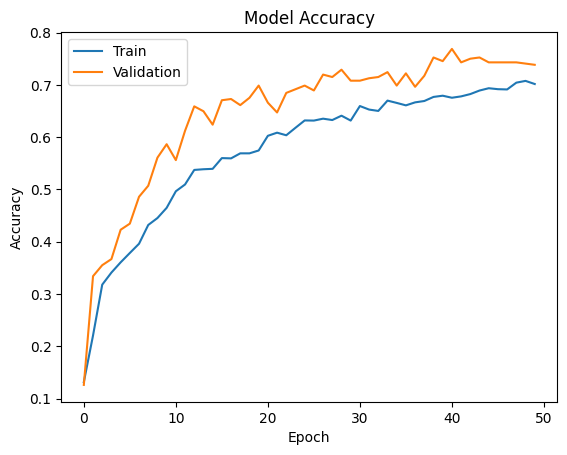

```python
plt.plot(history_2.history['accuracy'])
plt.plot(history_2.history['val_accuracy'])
plt.title('Model Accuracy')
plt.ylabel('Accuracy')
plt.xlabel('Epoch')
plt.legend(['Train', 'Validation'], loc='upper left')
plt.show()
```

**Evaluate the model on test data**

```python
accuracy = model2.evaluate(X_test_normalized, y_test_encoded, verbose=2)
```

```
15/15 - 3s - 187ms/step - accuracy: 0.7284 - loss: 0.9688
```

- Test accuracy is 73%.
- We can observe that our test accuracy has improved significantly compared to our previous model.

**Plotting the Confusion Matrix**

```python
# Here we would get the output as probablities for each category
y_pred=model2.predict(X_test_normalized)
```

```
15/15 ━━━━━━━━━━━━━━━━━━━━ 4s 234ms/step
```

```python
y_pred
```

```
array([[1.47827737e-21, 1.90656118e-16, 3.06505346e-20, ...,
        4.44325292e-03, 2.41627465e-11, 5.28743397e-03],
       [1.22273549e-30, 1.74544554e-03, 3.53871437e-05, ...,
        9.97191520e-08, 9.98218894e-01, 5.39486500e-09],
       [8.13433000e-20, 4.93324398e-15, 1.50724293e-15, ...,
        7.59328744e-13, 9.99992311e-01, 1.39126757e-06],
       ...,
       [2.69580007e-01, 6.62618452e-13, 3.64815327e-03, ...,
        4.96183199e-11, 4.71807107e-11, 4.98367939e-03],
       [5.47214695e-05, 6.26915251e-04, 1.21966854e-03, ...,
        1.22511968e-01, 2.23523821e-04, 1.68311000e-01],
       [1.06492695e-16, 5.58705882e-09, 6.88798180e-14, ...,
        5.22226654e-02, 2.68381894e-01, 4.40097321e-03]], dtype=float32)
```

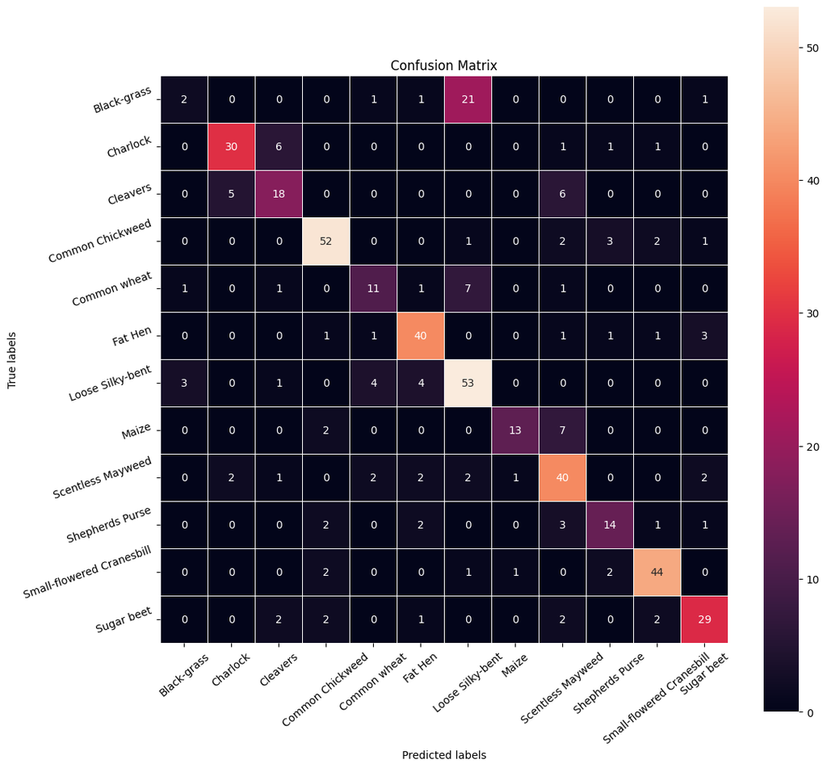

```python
# Obtaining the categorical values from y_test_encoded and y_pred
y_pred_arg=np.argmax(y_pred,axis=1)
y_test_arg=np.argmax(y_test_encoded,axis=1)

# Plotting the Confusion Matrix using confusion matrix() function which is also predefined in tensorflow module
confusion_matrix = tf.math.confusion_matrix(y_test_arg,y_pred_arg)
f, ax = plt.subplots(figsize=(12, 12))
sns.heatmap(
    confusion_matrix,
    annot=True,
    linewidths=.4,
    fmt="d",
    square=True,
    ax=ax
)
# Setting the labels to both the axes
ax.set_xlabel('Predicted labels');ax.set_ylabel('True labels');
ax.set_title('Confusion Matrix');
ax.xaxis.set_ticklabels(list(enc.classes_),rotation=40)
ax.yaxis.set_ticklabels(list(enc.classes_),rotation=20)
plt.show()
```

**Observations**

- We observe that the accuracy of this model improved to above 70%.
- Black-grass is still being majorly classified as Loose Silky-bent. There must be some largely indistinct similarities between these plant types.

**Plotting Classification Report**

```python
# Plotting the classification report
class_names=list(enc.classes_)
cr=classification_report(y_test_arg,y_pred_arg,target_names=class_names)
print(cr)
```

```
                           precision    recall  f1-score   support

              Black-grass       0.33      0.08      0.12        26
                 Charlock       0.81      0.77      0.79        39
                 Cleavers       0.62      0.62      0.62        29
         Common Chickweed       0.85      0.85      0.85        61
             Common wheat       0.58      0.50      0.54        22
                  Fat Hen       0.78      0.83      0.81        48
         Loose Silky-bent       0.62      0.82      0.71        65
                    Maize       0.87      0.59      0.70        22
        Scentless Mayweed       0.63      0.77      0.70        52
          Shepherds Purse       0.67      0.61      0.64        23
Small-flowered Cranesbill       0.86      0.88      0.87        50
               Sugar beet       0.78      0.76      0.77        38

                 accuracy                           0.73       475
                macro avg       0.70      0.67      0.68       475
             weighted avg       0.72      0.73      0.72       475
```

**Observations**

- Looking at the **Precision. Recall and f1-score**, Charlock, Common Chickweed, Fat Hen, Small-flowered Cranesbill and Sugar best, maintained high scores across all parameters, while Black-grass had lower scores across all parameters.
- In comparison to the rest, we observe the Small-flowered Cranesbill was classified at about 88% correctly, which was the most correctly classified category.

## Model Performance Improvement

**Reducing the Learning Rate:**

**ReduceLRonPlateau()** is a function that will be used to decrease the learning rate by some factor, if the loss is not decreasing for some time. This may start decreasing the loss at a smaller learning rate. There is a possibility that the loss may still not decrease. This may lead to executing the learning rate reduction again in an attempt to achieve a lower loss.

```python
# Code to monitor val_accuracy
learning_rate_reduction = ReduceLROnPlateau(monitor='val_accuracy',
                                            patience=3,
                                            verbose=1,
                                            factor=0.5,
                                            min_lr=0.00001)
```

### **Data Augmentation**

In most of the real-world case studies, it is challenging to acquire a large number of images and then train CNNs. To overcome this problem, one approach we might consider is Data Augmentation. CNNs have the property of translational invariance, which means they can recognise an object even if its appearance shifts translationally in some way. Taking this attribute into account, we can augment the images using the techniques listed below -

1. Horizontal Flip (should be set to True/False)
2. Vertical Flip (should be set to True/False)
3. Height Shift (should be between 0 and 1)
4. Width Shift (should be between 0 and 1)
5. Rotation (should be between 0 and 180)
6. Shear (should be between 0 and 1)
7. Zoom (should be between 0 and 1) etc.

Remember, data augmentation should not be used in the validation/test data set.

```python
# Clearing backend
from tensorflow.keras import backend
backend.clear_session()

# Fixing the seed for random number generators
import random
np.random.seed(42)
random.seed(42)
tf.random.set_seed(42)
```

```python
# Set the rotation_range to 20
train_datagen = ImageDataGenerator(
                              rotation_range=20,
                              fill_mode='nearest'
                              )
```

```python
# Intializing a sequential model
model3 = Sequential()

# Add the first conv layer with 64 filters and kernel size 3x3 , padding 'same' provides the output size same as the input size
# Input_shape denotes input image dimension images
model3.add(Conv2D(64, (3, 3), activation='relu', padding="same", input_shape=(64, 64, 3)))
# Add max pooling to reduce the size of output of first conv layer
model3.add(MaxPooling2D((2, 2), padding = 'same'))

model3.add(Conv2D(32, (3, 3), activation='relu', padding="same"))
model3.add(MaxPooling2D((2, 2), padding = 'same'))
model3.add(BatchNormalization())

# flattening the output of the conv layer after max pooling to make it ready for creating dense connections
model3.add(Flatten())

# Adding a fully connected dense layer with 16 neurons
model3.add(Dense(16, activation='relu'))

# Add dropout with dropout_rate=0.3
model3.add(Dropout(0.3))
# Add the output layer with 12 neurons and activation functions as softmax since this is a multi-class classification problem
model3.add(Dense(12, activation='softmax'))

# Initialize Adam Optimimzer
opt=Adam()

# Compile model
model3.compile(optimizer=opt, loss='categorical_crossentropy', metrics=['accuracy'])

# Generating the summary of the model
model3.summary()
```

```
Model: "sequential"
```

```
┏━━━━━━━━━━━━━━━━━━━━━━━━━━━━━━━━━━━━━━┳━━━━━━━━━━━━━━━━━━━━━━━━━━━━━┳━━━━━━━━━━━━━━━━━┓
┃ Layer (type)                         ┃ Output Shape                ┃         Param # ┃
┡━━━━━━━━━━━━━━━━━━━━━━━━━━━━━━━━━━━━━━╇━━━━━━━━━━━━━━━━━━━━━━━━━━━━━╇━━━━━━━━━━━━━━━━━┩
│ conv2d (Conv2D)                      │ (None, 64, 64, 64)          │           1,792 │
├──────────────────────────────────────┼─────────────────────────────┼─────────────────┤
│ max_pooling2d (MaxPooling2D)         │ (None, 32, 32, 64)          │               0 │
├──────────────────────────────────────┼─────────────────────────────┼─────────────────┤
│ conv2d_1 (Conv2D)                    │ (None, 32, 32, 32)          │          18,464 │
├──────────────────────────────────────┼─────────────────────────────┼─────────────────┤
│ max_pooling2d_1 (MaxPooling2D)       │ (None, 16, 16, 32)          │               0 │
├──────────────────────────────────────┼─────────────────────────────┼─────────────────┤
│ batch_normalization                  │ (None, 16, 16, 32)          │             128 │
│ (BatchNormalization)                 │                             │                 │
├──────────────────────────────────────┼─────────────────────────────┼─────────────────┤
│ flatten (Flatten)                    │ (None, 8192)                │               0 │
├──────────────────────────────────────┼─────────────────────────────┼─────────────────┤
│ dense (Dense)                        │ (None, 16)                  │         131,088 │
├──────────────────────────────────────┼─────────────────────────────┼─────────────────┤
│ dropout (Dropout)                    │ (None, 16)                  │               0 │
├──────────────────────────────────────┼─────────────────────────────┼─────────────────┤
│ dense_1 (Dense)                      │ (None, 12)                  │             204 │
└──────────────────────────────────────┴─────────────────────────────┴─────────────────┘
```

```
 Total params: 151,676 (592.48 KB)
```

```
 Trainable params: 151,612 (592.23 KB)
```

```
 Non-trainable params: 64 (256.00 B)
```

**Fitting the model on the train data**

**Model3 - Run 1**

- Data Augmentation => Applied \
- learning_rate_reduction function => Applied \
- Epochs=30 \
- Batch_Size=64

```python
# Fit the model on train data
# Epochs
epochs = 30
# Batch size
batch_size = 64

history = model3.fit(train_datagen.flow(X_train_normalized,y_train_encoded,
                                       batch_size=batch_size,
                                       shuffle=False),
                                       epochs=epochs,
                                       steps_per_epoch=X_train_normalized.shape[0] // batch_size,
                                       validation_data=(X_val_normalized,y_val_encoded),
                                       verbose=1,callbacks=[learning_rate_reduction])
```

```
60/60 ━━━━━━━━━━━━━━━━━━━━ 48s 758ms/step - accuracy: 0.1800 - loss: 2.3633 - val_accuracy: 0.3388 - val_loss: 2.4040 - learning_rate: 0.0010
60/60 ━━━━━━━━━━━━━━━━━━━━ 2s 17ms/step - accuracy: 0.4219 - loss: 1.6539 - val_accuracy: 0.3785 - val_loss: 2.4073 - learning_rate: 0.0010
60/60 ━━━━━━━━━━━━━━━━━━━━ 50s 823ms/step - accuracy: 0.3889 - loss: 1.8473 - val_accuracy: 0.2757 - val_loss: 2.3545 - learning_rate: 0.0010
60/60 ━━━━━━━━━━━━━━━━━━━━ 2s 17ms/step - accuracy: 0.4844 - loss: 1.6638 - val_accuracy: 0.2664 - val_loss: 2.3545 - learning_rate: 0.0010
60/60 ━━━━━━━━━━━━━━━━━━━━ 0s 686ms/step - accuracy: 0.4698 - loss: 1.6189
Epoch 5: ReduceLROnPlateau reducing learning rate to 0.0005000000237487257.
60/60 ━━━━━━━━━━━━━━━━━━━━ 44s 730ms/step - accuracy: 0.4700 - loss: 1.6181 - val_accuracy: 0.2967 - val_loss: 2.2817 - learning_rate: 0.0010
60/60 ━━━━━━━━━━━━━━━━━━━━ 1s 16ms/step - accuracy: 0.4844 - loss: 1.4837 - val_accuracy: 0.3037 - val_loss: 2.2703 - learning_rate: 5.0000e-04
60/60 ━━━━━━━━━━━━━━━━━━━━ 42s 691ms/step - accuracy: 0.5140 - loss: 1.4483 - val_accuracy: 0.3341 - val_loss: 2.1498 - learning_rate: 5.0000e-04
 1/60 ━━━━━━━━━━━━━━━━━━━━ 55s 936ms/step - accuracy: 0.5938 - loss: 1.2853
Epoch 8: ReduceLROnPlateau reducing learning rate to 0.0002500000118743628.
60/60 ━━━━━━━━━━━━━━━━━━━━ 3s 30ms/step - accuracy: 0.5938 - loss: 1.2853 - val_accuracy: 0.3481 - val_loss: 2.1440 - learning_rate: 5.0000e-04
60/60 ━━━━━━━━━━━━━━━━━━━━ 80s 699ms/step - accuracy: 0.5425 - loss: 1.3526 - val_accuracy: 0.5304 - val_loss: 1.9780 - learning_rate: 2.5000e-04
60/60 ━━━━━━━━━━━━━━━━━━━━ 2s 17ms/step - accuracy: 0.6250 - loss: 1.2339 - val_accuracy: 0.5280 - val_loss: 1.9710 - learning_rate: 2.5000e-04
60/60 ━━━━━━━━━━━━━━━━━━━━ 81s 722ms/step - accuracy: 0.5662 - loss: 1.2701 - val_accuracy: 0.5117 - val_loss: 1.8160 - learning_rate: 2.5000e-04
 1/60 ━━━━━━━━━━━━━━━━━━━━ 33s 565ms/step - accuracy: 0.4688 - loss: 1.3496
Epoch 12: ReduceLROnPlateau reducing learning rate to 0.0001250000059371814.
60/60 ━━━━━━━━━━━━━━━━━━━━ 1s 14ms/step - accuracy: 0.4688 - loss: 1.3496 - val_accuracy: 0.5304 - val_loss: 1.8035 - learning_rate: 2.5000e-04
60/60 ━━━━━━━━━━━━━━━━━━━━ 45s 735ms/step - accuracy: 0.5630 - loss: 1.2772 - val_accuracy: 0.6472 - val_loss: 1.6311 - learning_rate: 1.2500e-04
60/60 ━━━━━━━━━━━━━━━━━━━━ 2s 17ms/step - accuracy: 0.5469 - loss: 1.3838 - val_accuracy: 0.6472 - val_loss: 1.6198 - learning_rate: 1.2500e-04
60/60 ━━━━━━━━━━━━━━━━━━━━ 43s 709ms/step - accuracy: 0.5601 - loss: 1.2751 - val_accuracy: 0.6449 - val_loss: 1.4129 - learning_rate: 1.2500e-04
60/60 ━━━━━━━━━━━━━━━━━━━━ 3s 29ms/step - accuracy: 0.6875 - loss: 1.1002 - val_accuracy: 0.6542 - val_loss: 1.4149 - learning_rate: 1.2500e-04
60/60 ━━━━━━━━━━━━━━━━━━━━ 41s 679ms/step - accuracy: 0.5705 - loss: 1.2408 - val_accuracy: 0.6005 - val_loss: 1.3310 - learning_rate: 1.2500e-04
60/60 ━━━━━━━━━━━━━━━━━━━━ 3s 44ms/step - accuracy: 0.6719 - loss: 1.0164 - val_accuracy: 0.6075 - val_loss: 1.3237 - learning_rate: 1.2500e-04
60/60 ━━━━━━━━━━━━━━━━━━━━ 0s 674ms/step - accuracy: 0.5807 - loss: 1.2230
Epoch 19: ReduceLROnPlateau reducing learning rate to 6.25000029685907e-05.
60/60 ━━━━━━━━━━━━━━━━━━━━ 80s 689ms/step - accuracy: 0.5807 - loss: 1.2231 - val_accuracy: 0.6168 - val_loss: 1.2553 - learning_rate: 1.2500e-04
60/60 ━━━━━━━━━━━━━━━━━━━━ 1s 15ms/step - accuracy: 0.4688 - loss: 1.5870 - val_accuracy: 0.6215 - val_loss: 1.2491 - learning_rate: 6.2500e-05
60/60 ━━━━━━━━━━━━━━━━━━━━ 46s 753ms/step - accuracy: 0.5883 - loss: 1.2111 - val_accuracy: 0.6776 - val_loss: 1.1109 - learning_rate: 6.2500e-05
60/60 ━━━━━━━━━━━━━━━━━━━━ 1s 15ms/step - accuracy: 0.6250 - loss: 1.0741 - val_accuracy: 0.6752 - val_loss: 1.1084 - learning_rate: 6.2500e-05
60/60 ━━━━━━━━━━━━━━━━━━━━ 44s 722ms/step - accuracy: 0.5821 - loss: 1.2214 - val_accuracy: 0.6659 - val_loss: 1.0483 - learning_rate: 6.2500e-05
 1/60 ━━━━━━━━━━━━━━━━━━━━ 48s 828ms/step - accuracy: 0.5625 - loss: 1.2078
Epoch 24: ReduceLROnPlateau reducing learning rate to 3.125000148429535e-05.
60/60 ━━━━━━━━━━━━━━━━━━━━ 2s 15ms/step - accuracy: 0.5625 - loss: 1.2078 - val_accuracy: 0.6682 - val_loss: 1.0474 - learning_rate: 6.2500e-05
60/60 ━━━━━━━━━━━━━━━━━━━━ 80s 700ms/step - accuracy: 0.5873 - loss: 1.2069 - val_accuracy: 0.6706 - val_loss: 1.0379 - learning_rate: 3.1250e-05
60/60 ━━━━━━━━━━━━━━━━━━━━ 1s 15ms/step - accuracy: 0.5312 - loss: 1.2220 - val_accuracy: 0.6706 - val_loss: 1.0374 - learning_rate: 3.1250e-05
60/60 ━━━━━━━━━━━━━━━━━━━━ 0s 710ms/step - accuracy: 0.5877 - loss: 1.1901
Epoch 27: ReduceLROnPlateau reducing learning rate to 1.5625000742147677e-05.
60/60 ━━━━━━━━━━━━━━━━━━━━ 81s 726ms/step - accuracy: 0.5877 - loss: 1.1900 - val_accuracy: 0.6682 - val_loss: 1.0115 - learning_rate: 3.1250e-05
60/60 ━━━━━━━━━━━━━━━━━━━━ 2s 17ms/step - accuracy: 0.6719 - loss: 0.9562 - val_accuracy: 0.6659 - val_loss: 1.0114 - learning_rate: 1.5625e-05
60/60 ━━━━━━━━━━━━━━━━━━━━ 78s 687ms/step - accuracy: 0.6098 - loss: 1.1527 - val_accuracy: 0.6659 - val_loss: 1.0119 - learning_rate: 1.5625e-05
 1/60 ━━━━━━━━━━━━━━━━━━━━ 30s 510ms/step - accuracy: 0.5625 - loss: 1.2135
Epoch 30: ReduceLROnPlateau reducing learning rate to 1e-05.
60/60 ━━━━━━━━━━━━━━━━━━━━ 2s 29ms/step - accuracy: 0.5625 - loss: 1.2135 - val_accuracy: 0.6659 - val_loss: 1.0123 - learning_rate: 1.5625e-05
```

- Train accuracy is 56%; validation accuracy is 67%.

**Model3 - Run 2**

- Data Augmentation => Applied \
- learning_rate_reduction function => Applied \
- Epochs=50 \
- Batch_Size=32

```python
# Clearing backend
from tensorflow.keras import backend
backend.clear_session()

# Fixing the seed for random number generators
import random
np.random.seed(42)
random.seed(42)
tf.random.set_seed(42)
```

```python
# Set the rotation_range to 20
train_datagen = ImageDataGenerator(
                              rotation_range=20,
                              fill_mode='nearest'
                              )
```

```python
# Fit the model on train data
# Epochs
epochs = 50
# Batch size
batch_size = 32

history = model3.fit(train_datagen.flow(X_train_normalized,y_train_encoded,
                                       batch_size=batch_size,
                                       shuffle=False),
                                       epochs=epochs,
                                       steps_per_epoch=X_train_normalized.shape[0] // batch_size,
                                       validation_data=(X_val_normalized,y_val_encoded),
                                       verbose=1,callbacks=[learning_rate_reduction])
```

```
120/120 ━━━━━━━━━━━━━━━━━━━━ 42s 345ms/step - accuracy: 0.6029 - loss: 1.1782 - val_accuracy: 0.6659 - val_loss: 0.9967 - learning_rate: 1.0000e-05
120/120 ━━━━━━━━━━━━━━━━━━━━ 2s 14ms/step - accuracy: 0.6562 - loss: 0.8350 - val_accuracy: 0.6659 - val_loss: 0.9972 - learning_rate: 1.0000e-05
120/120 ━━━━━━━━━━━━━━━━━━━━ 45s 373ms/step - accuracy: 0.5958 - loss: 1.1569 - val_accuracy: 0.6706 - val_loss: 0.9942 - learning_rate: 1.0000e-05
120/120 ━━━━━━━━━━━━━━━━━━━━ 2s 13ms/step - accuracy: 0.6562 - loss: 1.1655 - val_accuracy: 0.6729 - val_loss: 0.9948 - learning_rate: 1.0000e-05
120/120 ━━━━━━━━━━━━━━━━━━━━ 79s 368ms/step - accuracy: 0.5885 - loss: 1.1617 - val_accuracy: 0.6776 - val_loss: 0.9892 - learning_rate: 1.0000e-05
120/120 ━━━━━━━━━━━━━━━━━━━━ 1s 9ms/step - accuracy: 0.6250 - loss: 1.2495 - val_accuracy: 0.6776 - val_loss: 0.9886 - learning_rate: 1.0000e-05
120/120 ━━━━━━━━━━━━━━━━━━━━ 77s 339ms/step - accuracy: 0.5818 - loss: 1.1903 - val_accuracy: 0.6636 - val_loss: 1.0021 - learning_rate: 1.0000e-05
120/120 ━━━━━━━━━━━━━━━━━━━━ 2s 14ms/step - accuracy: 0.6875 - loss: 1.1640 - val_accuracy: 0.6636 - val_loss: 1.0043 - learning_rate: 1.0000e-05
120/120 ━━━━━━━━━━━━━━━━━━━━ 82s 351ms/step - accuracy: 0.6054 - loss: 1.1811 - val_accuracy: 0.6776 - val_loss: 0.9853 - learning_rate: 1.0000e-05
120/120 ━━━━━━━━━━━━━━━━━━━━ 1s 7ms/step - accuracy: 0.5938 - loss: 1.1363 - val_accuracy: 0.6776 - val_loss: 0.9846 - learning_rate: 1.0000e-05
120/120 ━━━━━━━━━━━━━━━━━━━━ 82s 362ms/step - accuracy: 0.5819 - loss: 1.1792 - val_accuracy: 0.6729 - val_loss: 0.9839 - learning_rate: 1.0000e-05
120/120 ━━━━━━━━━━━━━━━━━━━━ 1s 9ms/step - accuracy: 0.4688 - loss: 1.3580 - val_accuracy: 0.6729 - val_loss: 0.9847 - learning_rate: 1.0000e-05
120/120 ━━━━━━━━━━━━━━━━━━━━ 80s 356ms/step - accuracy: 0.5963 - loss: 1.1738 - val_accuracy: 0.6659 - val_loss: 0.9883 - learning_rate: 1.0000e-05
120/120 ━━━━━━━━━━━━━━━━━━━━ 2s 15ms/step - accuracy: 0.5000 - loss: 1.5790 - val_accuracy: 0.6682 - val_loss: 0.9876 - learning_rate: 1.0000e-05
120/120 ━━━━━━━━━━━━━━━━━━━━ 79s 351ms/step - accuracy: 0.5926 - loss: 1.1929 - val_accuracy: 0.6822 - val_loss: 0.9747 - learning_rate: 1.0000e-05
120/120 ━━━━━━━━━━━━━━━━━━━━ 1s 8ms/step - accuracy: 0.5938 - loss: 1.0817 - val_accuracy: 0.6822 - val_loss: 0.9741 - learning_rate: 1.0000e-05
120/120 ━━━━━━━━━━━━━━━━━━━━ 44s 364ms/step - accuracy: 0.5891 - loss: 1.1762 - val_accuracy: 0.6636 - val_loss: 1.0029 - learning_rate: 1.0000e-05
120/120 ━━━━━━━━━━━━━━━━━━━━ 1s 9ms/step - accuracy: 0.6875 - loss: 1.0145 - val_accuracy: 0.6636 - val_loss: 1.0034 - learning_rate: 1.0000e-05
120/120 ━━━━━━━━━━━━━━━━━━━━ 44s 363ms/step - accuracy: 0.5834 - loss: 1.1959 - val_accuracy: 0.6776 - val_loss: 0.9961 - learning_rate: 1.0000e-05
120/120 ━━━━━━━━━━━━━━━━━━━━ 2s 14ms/step - accuracy: 0.6250 - loss: 0.9990 - val_accuracy: 0.6776 - val_loss: 0.9966 - learning_rate: 1.0000e-05
120/120 ━━━━━━━━━━━━━━━━━━━━ 81s 368ms/step - accuracy: 0.5776 - loss: 1.1905 - val_accuracy: 0.6822 - val_loss: 0.9761 - learning_rate: 1.0000e-05
120/120 ━━━━━━━━━━━━━━━━━━━━ 1s 8ms/step - accuracy: 0.5938 - loss: 1.2214 - val_accuracy: 0.6822 - val_loss: 0.9755 - learning_rate: 1.0000e-05
120/120 ━━━━━━━━━━━━━━━━━━━━ 43s 353ms/step - accuracy: 0.6096 - loss: 1.1249 - val_accuracy: 0.6682 - val_loss: 0.9814 - learning_rate: 1.0000e-05
120/120 ━━━━━━━━━━━━━━━━━━━━ 1s 7ms/step - accuracy: 0.4688 - loss: 1.2048 - val_accuracy: 0.6659 - val_loss: 0.9819 - learning_rate: 1.0000e-05
120/120 ━━━━━━━━━━━━━━━━━━━━ 41s 339ms/step - accuracy: 0.6049 - loss: 1.1445 - val_accuracy: 0.6822 - val_loss: 0.9664 - learning_rate: 1.0000e-05
120/120 ━━━━━━━━━━━━━━━━━━━━ 2s 11ms/step - accuracy: 0.6562 - loss: 1.0590 - val_accuracy: 0.6822 - val_loss: 0.9665 - learning_rate: 1.0000e-05
120/120 ━━━━━━━━━━━━━━━━━━━━ 43s 354ms/step - accuracy: 0.5830 - loss: 1.2057 - val_accuracy: 0.6822 - val_loss: 0.9617 - learning_rate: 1.0000e-05
120/120 ━━━━━━━━━━━━━━━━━━━━ 1s 7ms/step - accuracy: 0.5938 - loss: 1.1521 - val_accuracy: 0.6822 - val_loss: 0.9615 - learning_rate: 1.0000e-05
120/120 ━━━━━━━━━━━━━━━━━━━━ 82s 365ms/step - accuracy: 0.6183 - loss: 1.1198 - val_accuracy: 0.6706 - val_loss: 0.9741 - learning_rate: 1.0000e-05
120/120 ━━━━━━━━━━━━━━━━━━━━ 2s 11ms/step - accuracy: 0.7500 - loss: 0.7711 - val_accuracy: 0.6706 - val_loss: 0.9732 - learning_rate: 1.0000e-05
120/120 ━━━━━━━━━━━━━━━━━━━━ 42s 344ms/step - accuracy: 0.5999 - loss: 1.1656 - val_accuracy: 0.6776 - val_loss: 0.9662 - learning_rate: 1.0000e-05
120/120 ━━━━━━━━━━━━━━━━━━━━ 2s 15ms/step - accuracy: 0.6250 - loss: 0.9135 - val_accuracy: 0.6752 - val_loss: 0.9666 - learning_rate: 1.0000e-05
120/120 ━━━━━━━━━━━━━━━━━━━━ 80s 345ms/step - accuracy: 0.5980 - loss: 1.1693 - val_accuracy: 0.6706 - val_loss: 0.9790 - learning_rate: 1.0000e-05
```

[output cut: 17 more lines]

- Train accuracy is 53%; validation accuracy is 68%.

**Model3 - Run 3**

- Data Augmentation => Applied \
- learning_rate_reduction function => Not Applied \
- Epochs=50 \
- Batch_Size=32

```python
# Clearing backend
from tensorflow.keras import backend
backend.clear_session()

# Fixing the seed for random number generators
import random
np.random.seed(42)
random.seed(42)
tf.random.set_seed(42)
```

```python
# Set the rotation_range to 20
train_datagen = ImageDataGenerator(
                              rotation_range=20,
                              fill_mode='nearest'
                              )
```

```python
# Fit the model on train data
# Epochs
epochs = 50
# Batch size
batch_size = 32

history = model3.fit(train_datagen.flow(X_train_normalized,y_train_encoded,
                                       batch_size=batch_size,
                                       shuffle=False),
                                       epochs=epochs,
                                       steps_per_epoch=X_train_normalized.shape[0] // batch_size,
                                       validation_data=(X_val_normalized,y_val_encoded),
                                       verbose=1)
```

```
120/120 ━━━━━━━━━━━━━━━━━━━━ 42s 348ms/step - accuracy: 0.5930 - loss: 1.1611 - val_accuracy: 0.6846 - val_loss: 0.9605
120/120 ━━━━━━━━━━━━━━━━━━━━ 2s 14ms/step - accuracy: 0.6875 - loss: 0.7733 - val_accuracy: 0.6846 - val_loss: 0.9605
120/120 ━━━━━━━━━━━━━━━━━━━━ 82s 365ms/step - accuracy: 0.6242 - loss: 1.1165 - val_accuracy: 0.6799 - val_loss: 0.9444
120/120 ━━━━━━━━━━━━━━━━━━━━ 1s 8ms/step - accuracy: 0.5625 - loss: 1.3418 - val_accuracy: 0.6799 - val_loss: 0.9449
120/120 ━━━━━━━━━━━━━━━━━━━━ 43s 360ms/step - accuracy: 0.5926 - loss: 1.1422 - val_accuracy: 0.6846 - val_loss: 0.9437
120/120 ━━━━━━━━━━━━━━━━━━━━ 1s 9ms/step - accuracy: 0.6875 - loss: 1.0184 - val_accuracy: 0.6846 - val_loss: 0.9427
120/120 ━━━━━━━━━━━━━━━━━━━━ 44s 367ms/step - accuracy: 0.5931 - loss: 1.1394 - val_accuracy: 0.6776 - val_loss: 0.9563
120/120 ━━━━━━━━━━━━━━━━━━━━ 1s 9ms/step - accuracy: 0.6562 - loss: 1.1048 - val_accuracy: 0.6776 - val_loss: 0.9572
120/120 ━━━━━━━━━━━━━━━━━━━━ 56s 462ms/step - accuracy: 0.5985 - loss: 1.1416 - val_accuracy: 0.6752 - val_loss: 0.9675
120/120 ━━━━━━━━━━━━━━━━━━━━ 3s 19ms/step - accuracy: 0.6562 - loss: 1.1398 - val_accuracy: 0.6752 - val_loss: 0.9667
120/120 ━━━━━━━━━━━━━━━━━━━━ 80s 468ms/step - accuracy: 0.6163 - loss: 1.1043 - val_accuracy: 0.6869 - val_loss: 0.9469
120/120 ━━━━━━━━━━━━━━━━━━━━ 3s 22ms/step - accuracy: 0.6250 - loss: 1.1796 - val_accuracy: 0.6846 - val_loss: 0.9475
120/120 ━━━━━━━━━━━━━━━━━━━━ 57s 471ms/step - accuracy: 0.6119 - loss: 1.1331 - val_accuracy: 0.6822 - val_loss: 0.9518
120/120 ━━━━━━━━━━━━━━━━━━━━ 1s 8ms/step - accuracy: 0.5938 - loss: 1.2626 - val_accuracy: 0.6822 - val_loss: 0.9518
120/120 ━━━━━━━━━━━━━━━━━━━━ 73s 411ms/step - accuracy: 0.5814 - loss: 1.1838 - val_accuracy: 0.6963 - val_loss: 0.9314
120/120 ━━━━━━━━━━━━━━━━━━━━ 1s 9ms/step - accuracy: 0.6250 - loss: 0.9192 - val_accuracy: 0.6963 - val_loss: 0.9312
120/120 ━━━━━━━━━━━━━━━━━━━━ 54s 443ms/step - accuracy: 0.6121 - loss: 1.1228 - val_accuracy: 0.6846 - val_loss: 0.9448
120/120 ━━━━━━━━━━━━━━━━━━━━ 2s 15ms/step - accuracy: 0.6875 - loss: 0.9852 - val_accuracy: 0.6869 - val_loss: 0.9448
120/120 ━━━━━━━━━━━━━━━━━━━━ 42s 344ms/step - accuracy: 0.6176 - loss: 1.1176 - val_accuracy: 0.6846 - val_loss: 0.9502
120/120 ━━━━━━━━━━━━━━━━━━━━ 1s 9ms/step - accuracy: 0.6875 - loss: 0.9436 - val_accuracy: 0.6822 - val_loss: 0.9508
120/120 ━━━━━━━━━━━━━━━━━━━━ 50s 416ms/step - accuracy: 0.6074 - loss: 1.1103 - val_accuracy: 0.6893 - val_loss: 0.9300
120/120 ━━━━━━━━━━━━━━━━━━━━ 2s 16ms/step - accuracy: 0.5000 - loss: 1.2294 - val_accuracy: 0.6893 - val_loss: 0.9299
120/120 ━━━━━━━━━━━━━━━━━━━━ 78s 403ms/step - accuracy: 0.6197 - loss: 1.1021 - val_accuracy: 0.6846 - val_loss: 0.9552
120/120 ━━━━━━━━━━━━━━━━━━━━ 1s 9ms/step - accuracy: 0.6250 - loss: 0.9854 - val_accuracy: 0.6869 - val_loss: 0.9544
120/120 ━━━━━━━━━━━━━━━━━━━━ 77s 370ms/step - accuracy: 0.6106 - loss: 1.1094 - val_accuracy: 0.7033 - val_loss: 0.9202
120/120 ━━━━━━━━━━━━━━━━━━━━ 3s 22ms/step - accuracy: 0.6562 - loss: 1.0387 - val_accuracy: 0.7009 - val_loss: 0.9201
120/120 ━━━━━━━━━━━━━━━━━━━━ 79s 370ms/step - accuracy: 0.5909 - loss: 1.1630 - val_accuracy: 0.6893 - val_loss: 0.9268
120/120 ━━━━━━━━━━━━━━━━━━━━ 1s 9ms/step - accuracy: 0.6875 - loss: 0.9746 - val_accuracy: 0.6893 - val_loss: 0.9270
120/120 ━━━━━━━━━━━━━━━━━━━━ 43s 354ms/step - accuracy: 0.6152 - loss: 1.0968 - val_accuracy: 0.6963 - val_loss: 0.9234
120/120 ━━━━━━━━━━━━━━━━━━━━ 3s 22ms/step - accuracy: 0.7500 - loss: 0.8979 - val_accuracy: 0.6963 - val_loss: 0.9231
120/120 ━━━━━━━━━━━━━━━━━━━━ 80s 360ms/step - accuracy: 0.6097 - loss: 1.1135 - val_accuracy: 0.7009 - val_loss: 0.9258
120/120 ━━━━━━━━━━━━━━━━━━━━ 1s 9ms/step - accuracy: 0.6875 - loss: 0.9527 - val_accuracy: 0.6986 - val_loss: 0.9269
120/120 ━━━━━━━━━━━━━━━━━━━━ 44s 367ms/step - accuracy: 0.6065 - loss: 1.1163 - val_accuracy: 0.6846 - val_loss: 0.9423
120/120 ━━━━━━━━━━━━━━━━━━━━ 1s 9ms/step - accuracy: 0.5000 - loss: 1.3336 - val_accuracy: 0.6822 - val_loss: 0.9439
120/120 ━━━━━━━━━━━━━━━━━━━━ 80s 366ms/step - accuracy: 0.5988 - loss: 1.1055 - val_accuracy: 0.6869 - val_loss: 0.9542
120/120 ━━━━━━━━━━━━━━━━━━━━ 1s 9ms/step - accuracy: 0.5625 - loss: 1.1620 - val_accuracy: 0.6869 - val_loss: 0.9528
120/120 ━━━━━━━━━━━━━━━━━━━━ 42s 351ms/step - accuracy: 0.6160 - loss: 1.0977 - val_accuracy: 0.6963 - val_loss: 0.9252
120/120 ━━━━━━━━━━━━━━━━━━━━ 3s 22ms/step - accuracy: 0.7188 - loss: 1.0072 - val_accuracy: 0.6963 - val_loss: 0.9252
120/120 ━━━━━━━━━━━━━━━━━━━━ 42s 344ms/step - accuracy: 0.6163 - loss: 1.1101 - val_accuracy: 0.6963 - val_loss: 0.9249
120/120 ━━━━━━━━━━━━━━━━━━━━ 1s 9ms/step - accuracy: 0.5625 - loss: 0.9603 - val_accuracy: 0.6963 - val_loss: 0.9245
120/120 ━━━━━━━━━━━━━━━━━━━━ 44s 365ms/step - accuracy: 0.6077 - loss: 1.1310 - val_accuracy: 0.6893 - val_loss: 0.9371
120/120 ━━━━━━━━━━━━━━━━━━━━ 1s 9ms/step - accuracy: 0.5000 - loss: 1.2082 - val_accuracy: 0.6893 - val_loss: 0.9367
120/120 ━━━━━━━━━━━━━━━━━━━━ 45s 371ms/step - accuracy: 0.6226 - loss: 1.0613 - val_accuracy: 0.6986 - val_loss: 0.9153
120/120 ━━━━━━━━━━━━━━━━━━━━ 1s 9ms/step - accuracy: 0.6875 - loss: 1.2744 - val_accuracy: 0.7033 - val_loss: 0.9164
120/120 ━━━━━━━━━━━━━━━━━━━━ 44s 367ms/step - accuracy: 0.6154 - loss: 1.1094 - val_accuracy: 0.6846 - val_loss: 0.9301
120/120 ━━━━━━━━━━━━━━━━━━━━ 1s 9ms/step - accuracy: 0.5625 - loss: 1.1062 - val_accuracy: 0.6869 - val_loss: 0.9304
120/120 ━━━━━━━━━━━━━━━━━━━━ 79s 350ms/step - accuracy: 0.6050 - loss: 1.0950 - val_accuracy: 0.6869 - val_loss: 0.9303
120/120 ━━━━━━━━━━━━━━━━━━━━ 1s 9ms/step - accuracy: 0.5938 - loss: 1.0189 - val_accuracy: 0.6869 - val_loss: 0.9298
120/120 ━━━━━━━━━━━━━━━━━━━━ 45s 370ms/step - accuracy: 0.6153 - loss: 1.0989 - val_accuracy: 0.6869 - val_loss: 0.9365
120/120 ━━━━━━━━━━━━━━━━━━━━ 1s 9ms/step - accuracy: 0.5625 - loss: 1.3518 - val_accuracy: 0.6869 - val_loss: 0.9368
```

- Train accuracy is 56%; validation accuracy is 69%.

**Observations**

- Data Augmentation was applied to this model.
- I applied the **learning_rate_reduction** function to the first two model runs with different parameters and did the third run without the function applied.
- Train accuracy is way lower than the validation accuracy in this model. This could be due to inadequate training, small data set, regularization amongst others.
- All the runs were similar in accuracy. So, we will use the last one.

**Model Evaluation**

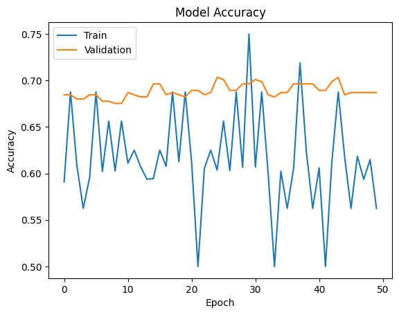

```python
plt.plot(history.history['accuracy'])
plt.plot(history.history['val_accuracy'])
plt.title('Model Accuracy')
plt.ylabel('Accuracy')
plt.xlabel('Epoch')
plt.legend(['Train', 'Validation'], loc='upper left')
plt.show()
```

**Evaluate the model on test data**

```python
accuracy = model3.evaluate(X_test_normalized, y_test_encoded, verbose=2)
```

```
15/15 - 1s - 69ms/step - accuracy: 0.6842 - loss: 0.9835
```

- Test accuracy is 68%.
- Test accuracy worsened in this model compared to the previous model.

**Plotting the Confusion Matrix**

```python
# Obtain the output probabilities
y_pred=model3.predict(X_test_normalized)
```

```
15/15 ━━━━━━━━━━━━━━━━━━━━ 2s 115ms/step
```

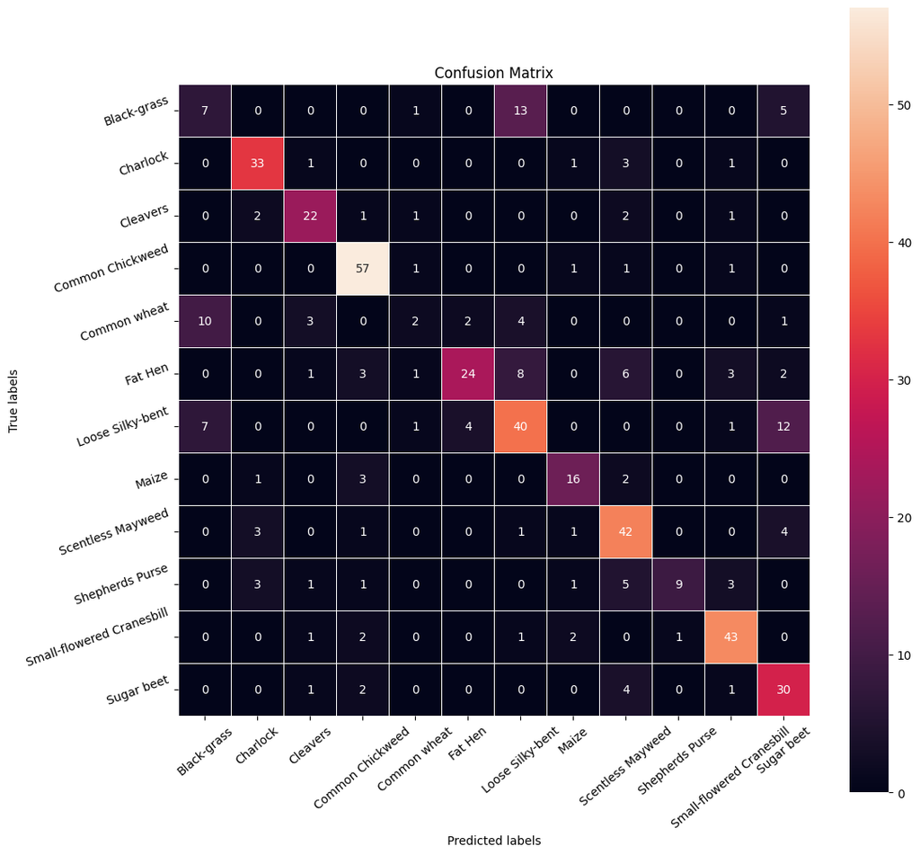

```python
# Obtaining the categorical values from y_test_encoded and y_pred
y_pred_arg=np.argmax(y_pred,axis=1)
y_test_arg=np.argmax(y_test_encoded,axis=1)

# Plotting the Confusion Matrix using confusion matrix() function which is also predefined in tensorflow module
confusion_matrix = tf.math.confusion_matrix(y_test_arg,y_pred_arg)
f, ax = plt.subplots(figsize=(12, 12))
sns.heatmap(
    confusion_matrix,
    annot=True,
    linewidths=.4,
    fmt="d",
    square=True,
    ax=ax
)
# Setting the labels to both the axes
ax.set_xlabel('Predicted labels');ax.set_ylabel('True labels');
ax.set_title('Confusion Matrix');
ax.xaxis.set_ticklabels(list(enc.classes_),rotation=40)
ax.yaxis.set_ticklabels(list(enc.classes_),rotation=20)
plt.show()
```

**Observations**

- Again, Black-grass is still being majorly classified as Loose Silky-bent. There must be some largely indistinct similarities between these plant types.

**Plotting Classification Report**

```python
y_test_arg
```

[output not shown]

```python
y_pred_arg
```

[output not shown]

```python
# Plotting the classification report
class_names=list(enc.classes_)
cr=classification_report(y_test_arg,y_pred_arg,target_names=class_names)
print(cr)
```

```
                           precision    recall  f1-score   support

              Black-grass       0.29      0.27      0.28        26
                 Charlock       0.79      0.85      0.81        39
                 Cleavers       0.73      0.76      0.75        29
         Common Chickweed       0.81      0.93      0.87        61
             Common wheat       0.29      0.09      0.14        22
                  Fat Hen       0.80      0.50      0.62        48
         Loose Silky-bent       0.60      0.62      0.61        65
                    Maize       0.73      0.73      0.73        22
        Scentless Mayweed       0.65      0.81      0.72        52
          Shepherds Purse       0.90      0.39      0.55        23
Small-flowered Cranesbill       0.80      0.86      0.83        50
               Sugar beet       0.56      0.79      0.65        38

                 accuracy                           0.68       475
                macro avg       0.66      0.63      0.63       475
             weighted avg       0.68      0.68      0.67       475
```

**Observations**

## Transfer Learning Model

- Let's try again, but this time, we will be using the idea of Transfer Learning. We will be loading a pre-built architecture - VGG16, which was trained on the ImageNet dataset and is the runner-up in the ImageNet competition in 2014.
- For training VGG16, we will directly use the convolutional and pooling layers and freeze their weights i.e. no training will be done on them. For classification, we will replace the existing fully-connected layers with FC layers created specifically for our problem.

```python
# Clearing backend
from tensorflow.keras import backend
backend.clear_session()

# Fixing the seed for random number generators
import random
np.random.seed(42)
random.seed(42)
tf.random.set_seed(42)
```

```python
from tensorflow.keras.models import Model
from keras.applications.vgg16 import VGG16

vgg_model = VGG16(weights='imagenet', include_top = False, input_shape = (64,64,3))
vgg_model.summary()
```

```
Model: "vgg16"
```

```
┏━━━━━━━━━━━━━━━━━━━━━━━━━━━━━━━━━━━━━━┳━━━━━━━━━━━━━━━━━━━━━━━━━━━━━┳━━━━━━━━━━━━━━━━━┓
┃ Layer (type)                         ┃ Output Shape                ┃         Param # ┃
┡━━━━━━━━━━━━━━━━━━━━━━━━━━━━━━━━━━━━━━╇━━━━━━━━━━━━━━━━━━━━━━━━━━━━━╇━━━━━━━━━━━━━━━━━┩
│ input_layer (InputLayer)             │ (None, 64, 64, 3)           │               0 │
├──────────────────────────────────────┼─────────────────────────────┼─────────────────┤
│ block1_conv1 (Conv2D)                │ (None, 64, 64, 64)          │           1,792 │
├──────────────────────────────────────┼─────────────────────────────┼─────────────────┤
│ block1_conv2 (Conv2D)                │ (None, 64, 64, 64)          │          36,928 │
├──────────────────────────────────────┼─────────────────────────────┼─────────────────┤
│ block1_pool (MaxPooling2D)           │ (None, 32, 32, 64)          │               0 │
├──────────────────────────────────────┼─────────────────────────────┼─────────────────┤
│ block2_conv1 (Conv2D)                │ (None, 32, 32, 128)         │          73,856 │
├──────────────────────────────────────┼─────────────────────────────┼─────────────────┤
│ block2_conv2 (Conv2D)                │ (None, 32, 32, 128)         │         147,584 │
├──────────────────────────────────────┼─────────────────────────────┼─────────────────┤
│ block2_pool (MaxPooling2D)           │ (None, 16, 16, 128)         │               0 │
├──────────────────────────────────────┼─────────────────────────────┼─────────────────┤
│ block3_conv1 (Conv2D)                │ (None, 16, 16, 256)         │         295,168 │
├──────────────────────────────────────┼─────────────────────────────┼─────────────────┤
│ block3_conv2 (Conv2D)                │ (None, 16, 16, 256)         │         590,080 │
├──────────────────────────────────────┼─────────────────────────────┼─────────────────┤
│ block3_conv3 (Conv2D)                │ (None, 16, 16, 256)         │         590,080 │
├──────────────────────────────────────┼─────────────────────────────┼─────────────────┤
│ block3_pool (MaxPooling2D)           │ (None, 8, 8, 256)           │               0 │
├──────────────────────────────────────┼─────────────────────────────┼─────────────────┤
│ block4_conv1 (Conv2D)                │ (None, 8, 8, 512)           │       1,180,160 │
├──────────────────────────────────────┼─────────────────────────────┼─────────────────┤
│ block4_conv2 (Conv2D)                │ (None, 8, 8, 512)           │       2,359,808 │
├──────────────────────────────────────┼─────────────────────────────┼─────────────────┤
│ block4_conv3 (Conv2D)                │ (None, 8, 8, 512)           │       2,359,808 │
├──────────────────────────────────────┼─────────────────────────────┼─────────────────┤
│ block4_pool (MaxPooling2D)           │ (None, 4, 4, 512)           │               0 │
├──────────────────────────────────────┼─────────────────────────────┼─────────────────┤
│ block5_conv1 (Conv2D)                │ (None, 4, 4, 512)           │       2,359,808 │
├──────────────────────────────────────┼─────────────────────────────┼─────────────────┤
│ block5_conv2 (Conv2D)                │ (None, 4, 4, 512)           │       2,359,808 │
├──────────────────────────────────────┼─────────────────────────────┼─────────────────┤
│ block5_conv3 (Conv2D)                │ (None, 4, 4, 512)           │       2,359,808 │
├──────────────────────────────────────┼─────────────────────────────┼─────────────────┤
│ block5_pool (MaxPooling2D)           │ (None, 2, 2, 512)           │               0 │
└──────────────────────────────────────┴─────────────────────────────┴─────────────────┘
```

```
 Total params: 14,714,688 (56.13 MB)
```

```
 Trainable params: 14,714,688 (56.13 MB)
```

```
 Non-trainable params: 0 (0.00 B)
```

```python
# Making all the layers of the VGG model non-trainable. i.e. freezing them
for layer in vgg_model.layers:
    layer.trainable = False
```

```python
new_model = Sequential()

# Adding the convolutional part of the VGG16 model from above
new_model.add(vgg_model)

# Flattening the output of the VGG16 model because it is from a convolutional layer
new_model.add(Flatten())

# Adding a dense output layer
new_model.add(Dense(32, activation='relu'))
new_model.add(Dropout(0.3))
new_model.add(Dense(16, activation='relu'))
new_model.add(Dense(12, activation='softmax'))
opt=Adam()
# Compile model
new_model.compile(optimizer=opt, loss='categorical_crossentropy', metrics=['accuracy'])

# Generating the summary of the model
new_model.summary()
```

```
Model: "sequential_1"
```

```
┏━━━━━━━━━━━━━━━━━━━━━━━━━━━━━━━━━━━━━━┳━━━━━━━━━━━━━━━━━━━━━━━━━━━━━┳━━━━━━━━━━━━━━━━━┓
┃ Layer (type)                         ┃ Output Shape                ┃         Param # ┃
┡━━━━━━━━━━━━━━━━━━━━━━━━━━━━━━━━━━━━━━╇━━━━━━━━━━━━━━━━━━━━━━━━━━━━━╇━━━━━━━━━━━━━━━━━┩
│ vgg16 (Functional)                   │ (None, 2, 2, 512)           │      14,714,688 │
├──────────────────────────────────────┼─────────────────────────────┼─────────────────┤
│ flatten_1 (Flatten)                  │ (None, 2048)                │               0 │
├──────────────────────────────────────┼─────────────────────────────┼─────────────────┤
│ dense_2 (Dense)                      │ (None, 32)                  │          65,568 │
├──────────────────────────────────────┼─────────────────────────────┼─────────────────┤
│ dropout_1 (Dropout)                  │ (None, 32)                  │               0 │
├──────────────────────────────────────┼─────────────────────────────┼─────────────────┤
│ dense_3 (Dense)                      │ (None, 16)                  │             528 │
├──────────────────────────────────────┼─────────────────────────────┼─────────────────┤
│ dense_4 (Dense)                      │ (None, 12)                  │             204 │
└──────────────────────────────────────┴─────────────────────────────┴─────────────────┘
```

```
 Total params: 14,780,988 (56.38 MB)
```

```
 Trainable params: 66,300 (258.98 KB)
```

```
 Non-trainable params: 14,714,688 (56.13 MB)
```

**Fit the model**

**Model4 - Run1**

- Data Augmentation - Applied
- Epochs=25
- Batch_Size=64

```python
# Epochs
epochs = 25
# Batch size
batch_size = 64

history_vgg16 = new_model.fit(train_datagen.flow(X_train_normalized,y_train_encoded,
                                       batch_size=batch_size,
                                       seed=42,
                                       shuffle=False),
                    epochs=epochs,
                    steps_per_epoch=X_train_normalized.shape[0] // batch_size,
                    validation_data=(X_val_normalized,y_val_encoded),
                    verbose=1)
```

```
60/60 ━━━━━━━━━━━━━━━━━━━━ 246s 4s/step - accuracy: 0.1637 - loss: 2.4269 - val_accuracy: 0.3037 - val_loss: 2.2568
60/60 ━━━━━━━━━━━━━━━━━━━━ 23s 351ms/step - accuracy: 0.3125 - loss: 2.2303 - val_accuracy: 0.2991 - val_loss: 2.2539
60/60 ━━━━━━━━━━━━━━━━━━━━ 267s 4s/step - accuracy: 0.2699 - loss: 2.1932 - val_accuracy: 0.3505 - val_loss: 2.0425
60/60 ━━━━━━━━━━━━━━━━━━━━ 23s 351ms/step - accuracy: 0.3125 - loss: 2.0392 - val_accuracy: 0.3505 - val_loss: 2.0403
60/60 ━━━━━━━━━━━━━━━━━━━━ 241s 4s/step - accuracy: 0.3235 - loss: 1.9835 - val_accuracy: 0.3645 - val_loss: 1.8697
60/60 ━━━━━━━━━━━━━━━━━━━━ 44s 694ms/step - accuracy: 0.4062 - loss: 1.9155 - val_accuracy: 0.3621 - val_loss: 1.8698
60/60 ━━━━━━━━━━━━━━━━━━━━ 222s 4s/step - accuracy: 0.3634 - loss: 1.8319 - val_accuracy: 0.3832 - val_loss: 1.7501
60/60 ━━━━━━━━━━━━━━━━━━━━ 24s 357ms/step - accuracy: 0.3750 - loss: 1.7389 - val_accuracy: 0.3855 - val_loss: 1.7484
60/60 ━━━━━━━━━━━━━━━━━━━━ 225s 4s/step - accuracy: 0.3938 - loss: 1.7314 - val_accuracy: 0.4089 - val_loss: 1.6993
60/60 ━━━━━━━━━━━━━━━━━━━━ 44s 694ms/step - accuracy: 0.4531 - loss: 1.7505 - val_accuracy: 0.4065 - val_loss: 1.6972
60/60 ━━━━━━━━━━━━━━━━━━━━ 219s 4s/step - accuracy: 0.4014 - loss: 1.6903 - val_accuracy: 0.4136 - val_loss: 1.6631
60/60 ━━━━━━━━━━━━━━━━━━━━ 27s 404ms/step - accuracy: 0.3750 - loss: 1.6402 - val_accuracy: 0.4159 - val_loss: 1.6613
60/60 ━━━━━━━━━━━━━━━━━━━━ 254s 4s/step - accuracy: 0.4124 - loss: 1.6499 - val_accuracy: 0.4463 - val_loss: 1.5899
60/60 ━━━━━━━━━━━━━━━━━━━━ 29s 431ms/step - accuracy: 0.5469 - loss: 1.5608 - val_accuracy: 0.4322 - val_loss: 1.5921
60/60 ━━━━━━━━━━━━━━━━━━━━ 222s 4s/step - accuracy: 0.4535 - loss: 1.5491 - val_accuracy: 0.4439 - val_loss: 1.5963
60/60 ━━━━━━━━━━━━━━━━━━━━ 26s 382ms/step - accuracy: 0.5312 - loss: 1.5612 - val_accuracy: 0.4346 - val_loss: 1.5881
60/60 ━━━━━━━━━━━━━━━━━━━━ 249s 4s/step - accuracy: 0.4580 - loss: 1.5197 - val_accuracy: 0.4463 - val_loss: 1.5348
60/60 ━━━━━━━━━━━━━━━━━━━━ 44s 695ms/step - accuracy: 0.4844 - loss: 1.4221 - val_accuracy: 0.4579 - val_loss: 1.5346
60/60 ━━━━━━━━━━━━━━━━━━━━ 253s 4s/step - accuracy: 0.4717 - loss: 1.4951 - val_accuracy: 0.4650 - val_loss: 1.5395
60/60 ━━━━━━━━━━━━━━━━━━━━ 44s 695ms/step - accuracy: 0.5469 - loss: 1.3528 - val_accuracy: 0.4743 - val_loss: 1.5342
60/60 ━━━━━━━━━━━━━━━━━━━━ 287s 4s/step - accuracy: 0.4779 - loss: 1.4649 - val_accuracy: 0.4696 - val_loss: 1.4971
60/60 ━━━━━━━━━━━━━━━━━━━━ 29s 449ms/step - accuracy: 0.5000 - loss: 1.3714 - val_accuracy: 0.4720 - val_loss: 1.4939
60/60 ━━━━━━━━━━━━━━━━━━━━ 240s 4s/step - accuracy: 0.4891 - loss: 1.4421 - val_accuracy: 0.4766 - val_loss: 1.4744
60/60 ━━━━━━━━━━━━━━━━━━━━ 44s 695ms/step - accuracy: 0.5469 - loss: 1.2256 - val_accuracy: 0.4883 - val_loss: 1.4825
60/60 ━━━━━━━━━━━━━━━━━━━━ 241s 4s/step - accuracy: 0.4989 - loss: 1.4315 - val_accuracy: 0.4930 - val_loss: 1.4440
```

- Train accuracy is 50%; validation accuracy is 49%.

**Model4 - Run2**

- Different ANN layers (Output Only)
- Data Augmentation - Applied
- Epochs=25
- Batch_Size=128

```python
new_model = Sequential()

# Adding the convolutional part of the VGG16 model from above
new_model.add(vgg_model)

# Flattening the output of the VGG16 model because it is from a convolutional layer
new_model.add(Flatten())

# Adding a dense output layer
#new_model.add(Dense(100, activation='relu'))
#new_model.add(Dropout(0.3))
#new_model.add(Dense(100, activation='relu'))
new_model.add(Dense(12, activation='softmax'))
opt=Adam()
# Compile model
new_model.compile(optimizer=opt, loss='categorical_crossentropy', metrics=['accuracy'])

# Generating the summary of the model
new_model.summary()
```

```
Model: "sequential"
```

```
┏━━━━━━━━━━━━━━━━━━━━━━━━━━━━━━━━━━━━━━┳━━━━━━━━━━━━━━━━━━━━━━━━━━━━━┳━━━━━━━━━━━━━━━━━┓
┃ Layer (type)                         ┃ Output Shape                ┃         Param # ┃
┡━━━━━━━━━━━━━━━━━━━━━━━━━━━━━━━━━━━━━━╇━━━━━━━━━━━━━━━━━━━━━━━━━━━━━╇━━━━━━━━━━━━━━━━━┩
│ vgg16 (Functional)                   │ (None, 2, 2, 512)           │      14,714,688 │
├──────────────────────────────────────┼─────────────────────────────┼─────────────────┤
│ flatten (Flatten)                    │ (None, 2048)                │               0 │
├──────────────────────────────────────┼─────────────────────────────┼─────────────────┤
│ dense (Dense)                        │ (None, 12)                  │          24,588 │
└──────────────────────────────────────┴─────────────────────────────┴─────────────────┘
```

```
 Total params: 14,739,276 (56.23 MB)
```

```
 Trainable params: 24,588 (96.05 KB)
```

```
 Non-trainable params: 14,714,688 (56.13 MB)
```

```python
# Epochs
epochs = 25
# Batch size
batch_size = 128

history_vgg16 = new_model.fit(train_datagen.flow(X_train_normalized,y_train_encoded,
                                       batch_size=batch_size,
                                       seed=42,
                                       shuffle=False),
                    epochs=epochs,
                    steps_per_epoch=X_train_normalized.shape[0] // batch_size,
                    validation_data=(X_val_normalized,y_val_encoded),
                    verbose=1)
```

```
30/30 ━━━━━━━━━━━━━━━━━━━━ 194s 6s/step - accuracy: 0.4134 - loss: 1.8061 - val_accuracy: 0.4042 - val_loss: 1.8263
30/30 ━━━━━━━━━━━━━━━━━━━━ 27s 643ms/step - accuracy: 0.4141 - loss: 1.7735 - val_accuracy: 0.4089 - val_loss: 1.8233
30/30 ━━━━━━━━━━━━━━━━━━━━ 193s 6s/step - accuracy: 0.4576 - loss: 1.7307 - val_accuracy: 0.4206 - val_loss: 1.7600
30/30 ━━━━━━━━━━━━━━━━━━━━ 26s 641ms/step - accuracy: 0.5156 - loss: 1.5812 - val_accuracy: 0.4229 - val_loss: 1.7596
30/30 ━━━━━━━━━━━━━━━━━━━━ 195s 7s/step - accuracy: 0.4708 - loss: 1.6510 - val_accuracy: 0.4276 - val_loss: 1.7262
30/30 ━━━━━━━━━━━━━━━━━━━━ 26s 702ms/step - accuracy: 0.5000 - loss: 1.5465 - val_accuracy: 0.4322 - val_loss: 1.7239
30/30 ━━━━━━━━━━━━━━━━━━━━ 195s 7s/step - accuracy: 0.4847 - loss: 1.5959 - val_accuracy: 0.4439 - val_loss: 1.7027
30/30 ━━━━━━━━━━━━━━━━━━━━ 24s 676ms/step - accuracy: 0.5000 - loss: 1.6191 - val_accuracy: 0.4416 - val_loss: 1.6966
30/30 ━━━━━━━━━━━━━━━━━━━━ 237s 6s/step - accuracy: 0.5095 - loss: 1.5638 - val_accuracy: 0.4486 - val_loss: 1.6549
30/30 ━━━━━━━━━━━━━━━━━━━━ 26s 703ms/step - accuracy: 0.5703 - loss: 1.4319 - val_accuracy: 0.4533 - val_loss: 1.6541
30/30 ━━━━━━━━━━━━━━━━━━━━ 235s 6s/step - accuracy: 0.5218 - loss: 1.5150 - val_accuracy: 0.4673 - val_loss: 1.6237
30/30 ━━━━━━━━━━━━━━━━━━━━ 46s 1s/step - accuracy: 0.5078 - loss: 1.4969 - val_accuracy: 0.4650 - val_loss: 1.6261
30/30 ━━━━━━━━━━━━━━━━━━━━ 194s 6s/step - accuracy: 0.5193 - loss: 1.4835 - val_accuracy: 0.4486 - val_loss: 1.6008
30/30 ━━━━━━━━━━━━━━━━━━━━ 26s 678ms/step - accuracy: 0.6094 - loss: 1.4798 - val_accuracy: 0.4556 - val_loss: 1.6010
30/30 ━━━━━━━━━━━━━━━━━━━━ 237s 6s/step - accuracy: 0.5520 - loss: 1.4377 - val_accuracy: 0.4533 - val_loss: 1.5758
30/30 ━━━━━━━━━━━━━━━━━━━━ 26s 629ms/step - accuracy: 0.5703 - loss: 1.4422 - val_accuracy: 0.4626 - val_loss: 1.5782
30/30 ━━━━━━━━━━━━━━━━━━━━ 259s 7s/step - accuracy: 0.5508 - loss: 1.4122 - val_accuracy: 0.4790 - val_loss: 1.5523
30/30 ━━━━━━━━━━━━━━━━━━━━ 33s 901ms/step - accuracy: 0.6016 - loss: 1.3177 - val_accuracy: 0.4766 - val_loss: 1.5514
30/30 ━━━━━━━━━━━━━━━━━━━━ 250s 8s/step - accuracy: 0.5774 - loss: 1.3931 - val_accuracy: 0.4720 - val_loss: 1.5285
30/30 ━━━━━━━━━━━━━━━━━━━━ 33s 773ms/step - accuracy: 0.5859 - loss: 1.3460 - val_accuracy: 0.4650 - val_loss: 1.5274
30/30 ━━━━━━━━━━━━━━━━━━━━ 196s 7s/step - accuracy: 0.5734 - loss: 1.3543 - val_accuracy: 0.4860 - val_loss: 1.5159
30/30 ━━━━━━━━━━━━━━━━━━━━ 25s 707ms/step - accuracy: 0.5391 - loss: 1.2958 - val_accuracy: 0.4790 - val_loss: 1.5137
30/30 ━━━━━━━━━━━━━━━━━━━━ 237s 7s/step - accuracy: 0.5801 - loss: 1.3162 - val_accuracy: 0.4860 - val_loss: 1.5008
30/30 ━━━━━━━━━━━━━━━━━━━━ 46s 1s/step - accuracy: 0.5156 - loss: 1.3436 - val_accuracy: 0.4790 - val_loss: 1.4990
30/30 ━━━━━━━━━━━━━━━━━━━━ 214s 6s/step - accuracy: 0.5851 - loss: 1.2975 - val_accuracy: 0.4626 - val_loss: 1.4961
```

- Train accuracy is 58%; validation accuracy is 46%. This is overfitting.

**Model4 - Run3**

```python
new_model = Sequential()

# Adding the convolutional part of the VGG16 model from above
new_model.add(vgg_model)

# Flattening the output of the VGG16 model because it is from a convolutional layer
new_model.add(Flatten())

# Adding a dense output layer
#new_model.add(Dense(100, activation='relu'))
#new_model.add(Dropout(0.3))
new_model.add(Dense(16, activation='relu'))
new_model.add(Dense(12, activation='softmax'))
opt=Adam()
# Compile model
new_model.compile(optimizer=opt, loss='categorical_crossentropy', metrics=['accuracy'])

# Generating the summary of the model
new_model.summary()
```

```
Model: "sequential"
```

```
┏━━━━━━━━━━━━━━━━━━━━━━━━━━━━━━━━━━━━━━┳━━━━━━━━━━━━━━━━━━━━━━━━━━━━━┳━━━━━━━━━━━━━━━━━┓
┃ Layer (type)                         ┃ Output Shape                ┃         Param # ┃
┡━━━━━━━━━━━━━━━━━━━━━━━━━━━━━━━━━━━━━━╇━━━━━━━━━━━━━━━━━━━━━━━━━━━━━╇━━━━━━━━━━━━━━━━━┩
│ vgg16 (Functional)                   │ (None, 2, 2, 512)           │      14,714,688 │
├──────────────────────────────────────┼─────────────────────────────┼─────────────────┤
│ flatten (Flatten)                    │ (None, 2048)                │               0 │
├──────────────────────────────────────┼─────────────────────────────┼─────────────────┤
│ dense (Dense)                        │ (None, 16)                  │          32,784 │
├──────────────────────────────────────┼─────────────────────────────┼─────────────────┤
│ dense_1 (Dense)                      │ (None, 12)                  │             204 │
└──────────────────────────────────────┴─────────────────────────────┴─────────────────┘
```

```
 Total params: 14,747,676 (56.26 MB)
```

```
 Trainable params: 32,988 (128.86 KB)
```

```
 Non-trainable params: 14,714,688 (56.13 MB)
```

```python
# Epochs
epochs = 25
# Batch size
batch_size = 128

history_vgg16 = new_model.fit(train_datagen.flow(X_train_normalized,y_train_encoded,
                                       batch_size=batch_size,
                                       seed=42,
                                       shuffle=False),
                    epochs=epochs,
                    steps_per_epoch=X_train_normalized.shape[0] // batch_size,
                    validation_data=(X_val_normalized,y_val_encoded),
                    verbose=1)
```

```
30/30 ━━━━━━━━━━━━━━━━━━━━ 246s 8s/step - accuracy: 0.0962 - loss: 2.4760 - val_accuracy: 0.1589 - val_loss: 2.3834
30/30 ━━━━━━━━━━━━━━━━━━━━ 47s 1s/step - accuracy: 0.1484 - loss: 2.3937 - val_accuracy: 0.1612 - val_loss: 2.3800
30/30 ━━━━━━━━━━━━━━━━━━━━ 292s 10s/step - accuracy: 0.1668 - loss: 2.3389 - val_accuracy: 0.2056 - val_loss: 2.3042
30/30 ━━━━━━━━━━━━━━━━━━━━ 30s 758ms/step - accuracy: 0.1953 - loss: 2.2775 - val_accuracy: 0.2079 - val_loss: 2.3000
30/30 ━━━━━━━━━━━━━━━━━━━━ 274s 9s/step - accuracy: 0.2237 - loss: 2.2340 - val_accuracy: 0.2991 - val_loss: 2.2111
30/30 ━━━━━━━━━━━━━━━━━━━━ 28s 784ms/step - accuracy: 0.3359 - loss: 2.1588 - val_accuracy: 0.3061 - val_loss: 2.2081
30/30 ━━━━━━━━━━━━━━━━━━━━ 268s 9s/step - accuracy: 0.3299 - loss: 2.1273 - val_accuracy: 0.3598 - val_loss: 2.0952
30/30 ━━━━━━━━━━━━━━━━━━━━ 47s 1s/step - accuracy: 0.3672 - loss: 2.0420 - val_accuracy: 0.3481 - val_loss: 2.0911
30/30 ━━━━━━━━━━━━━━━━━━━━ 278s 9s/step - accuracy: 0.3629 - loss: 2.0273 - val_accuracy: 0.3785 - val_loss: 1.9424
30/30 ━━━━━━━━━━━━━━━━━━━━ 36s 877ms/step - accuracy: 0.4141 - loss: 1.8011 - val_accuracy: 0.3808 - val_loss: 1.9392
30/30 ━━━━━━━━━━━━━━━━━━━━ 246s 8s/step - accuracy: 0.4009 - loss: 1.8590 - val_accuracy: 0.4182 - val_loss: 1.8307
30/30 ━━━━━━━━━━━━━━━━━━━━ 48s 1s/step - accuracy: 0.4453 - loss: 1.7786 - val_accuracy: 0.4019 - val_loss: 1.8309
30/30 ━━━━━━━━━━━━━━━━━━━━ 310s 9s/step - accuracy: 0.4230 - loss: 1.7464 - val_accuracy: 0.4159 - val_loss: 1.7738
30/30 ━━━━━━━━━━━━━━━━━━━━ 30s 737ms/step - accuracy: 0.5078 - loss: 1.6626 - val_accuracy: 0.4112 - val_loss: 1.7693
30/30 ━━━━━━━━━━━━━━━━━━━━ 281s 9s/step - accuracy: 0.4618 - loss: 1.6511 - val_accuracy: 0.4346 - val_loss: 1.7081
30/30 ━━━━━━━━━━━━━━━━━━━━ 29s 723ms/step - accuracy: 0.4453 - loss: 1.5921 - val_accuracy: 0.4322 - val_loss: 1.7090
30/30 ━━━━━━━━━━━━━━━━━━━━ 249s 8s/step - accuracy: 0.4755 - loss: 1.5834 - val_accuracy: 0.4299 - val_loss: 1.6631
30/30 ━━━━━━━━━━━━━━━━━━━━ 51s 1s/step - accuracy: 0.5312 - loss: 1.4567 - val_accuracy: 0.4416 - val_loss: 1.6580
30/30 ━━━━━━━━━━━━━━━━━━━━ 290s 9s/step - accuracy: 0.4950 - loss: 1.5346 - val_accuracy: 0.4533 - val_loss: 1.6117
30/30 ━━━━━━━━━━━━━━━━━━━━ 32s 838ms/step - accuracy: 0.5781 - loss: 1.5253 - val_accuracy: 0.4533 - val_loss: 1.6082
30/30 ━━━━━━━━━━━━━━━━━━━━ 259s 9s/step - accuracy: 0.4968 - loss: 1.4849 - val_accuracy: 0.4346 - val_loss: 1.5964
30/30 ━━━━━━━━━━━━━━━━━━━━ 33s 931ms/step - accuracy: 0.5469 - loss: 1.4166 - val_accuracy: 0.4393 - val_loss: 1.5919
30/30 ━━━━━━━━━━━━━━━━━━━━ 259s 8s/step - accuracy: 0.5198 - loss: 1.4224 - val_accuracy: 0.4509 - val_loss: 1.5659
30/30 ━━━━━━━━━━━━━━━━━━━━ 47s 1s/step - accuracy: 0.5000 - loss: 1.4408 - val_accuracy: 0.4509 - val_loss: 1.5696
30/30 ━━━━━━━━━━━━━━━━━━━━ 282s 8s/step - accuracy: 0.5224 - loss: 1.4036 - val_accuracy: 0.4720 - val_loss: 1.5397
```

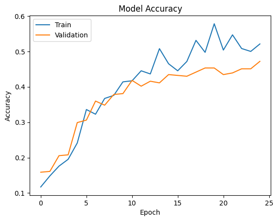

```python
plt.plot(history_vgg16.history['accuracy'])
plt.plot(history_vgg16.history['val_accuracy'])
plt.title('Model Accuracy')
plt.ylabel('Accuracy')
plt.xlabel('Epoch')
plt.legend(['Train', 'Validation'], loc='upper left')
plt.show()
```

```python
accuracy = new_model.evaluate(X_test_normalized, y_test_encoded, verbose=2)
```

```
15/15 - 31s - 2s/step - accuracy: 0.4989 - loss: 1.5127
```

```python
# Here we would get the output as probablities for each category
y_pred=new_model.predict(X_test_normalized)
```

```
15/15 ━━━━━━━━━━━━━━━━━━━━ 24s 2s/step
```

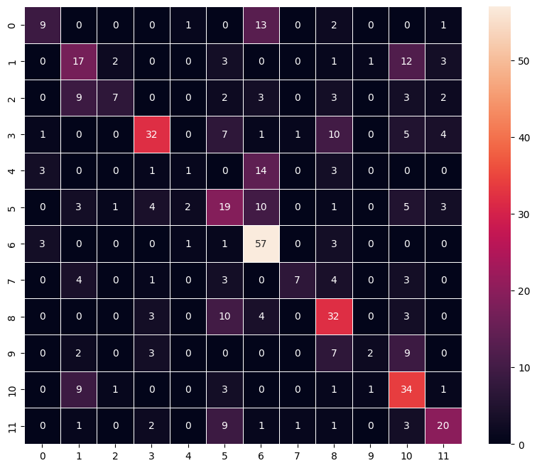

```python
# Obtaining the categorical values from y_test_encoded and y_pred
y_pred_arg=np.argmax(y_pred,axis=1)
y_test_arg=np.argmax(y_test_encoded,axis=1)

# Plotting the Confusion Matrix using confusion matrix() function which is also predefined tensorflow module
confusion_matrix = tf.math.confusion_matrix(y_test_arg,y_pred_arg)
f, ax = plt.subplots(figsize=(10, 8))
sns.heatmap(
    confusion_matrix,
    annot=True,
    linewidths=.4,
    fmt="d",
    square=True,
    ax=ax
)
plt.show()
```

**Observations**

- We can observe that there is a lot of misclassificaton going on.
- Again, Black-grass is still being majorly classified as Loose Silky-bent. There must be some largely indistinct similarities between these plant types.

**Plotting Classification Report**

```python
y_test_arg
```

[output not shown]

```python
y_pred_arg
```

[output not shown]

```python
# Plotting the classification report
class_names=list(enc.classes_)
cr=classification_report(y_test_arg,y_pred_arg,target_names=class_names)
print(cr)
```

```
                           precision    recall  f1-score   support

              Black-grass       0.56      0.35      0.43        26
                 Charlock       0.38      0.44      0.40        39
                 Cleavers       0.64      0.24      0.35        29
         Common Chickweed       0.70      0.52      0.60        61
             Common wheat       0.20      0.05      0.07        22
                  Fat Hen       0.33      0.40      0.36        48
         Loose Silky-bent       0.55      0.88      0.68        65
                    Maize       0.78      0.32      0.45        22
        Scentless Mayweed       0.47      0.62      0.53        52
          Shepherds Purse       0.50      0.09      0.15        23
Small-flowered Cranesbill       0.44      0.68      0.54        50
               Sugar beet       0.59      0.53      0.56        38

                 accuracy                           0.50       475
                macro avg       0.51      0.42      0.43       475
             weighted avg       0.51      0.50      0.48       475
```

**Observations**

- Looking at the **Precision. Recall and f1-score**, no category stands out as being classified well across all parameters.
- In comparison to the rest, we observe the Common wheat was classified at about 5% correctly, which was the most incorrectly classified category.

## Final Model

```python
pd.DataFrame({'Models':['Initial CNN Model','Second CNN Model','CNN Model with Data Augmentation','Transfer Learning Model'],'Train Accuracy':['68%','71%','56%','52%'],'Validation Accuracy':['62%','74%','69%','47%'],'Test Accuracy':['63%','73%','68%','50%']})
```

|  | Models | Train Accuracy | Validation Accuracy | Test Accuracy |
| --- | --- | --- | --- | --- |
| 0 | Initial CNN Model | 68% | 62% | 63% |
| 1 | Second CNN Model | 71% | 74% | 73% |
| 2 | CNN Model with Data Augmentation | 56% | 69% | 68% |
| 3 | Transfer Learning Model | 52% | 47% | 50% |

### **Conclusion**

- We can observe from the confusion matrix of all the models that the Second CNN model was the best model because it predicted the majority of the classes better than the other models.
- The test accuracy of the Second CNN model is 73%.

### Visualizing the prediction

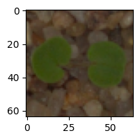

```
1/1 ━━━━━━━━━━━━━━━━━━━━ 0s 43ms/step
Predicted Label ['Small-flowered Cranesbill']
True Label Small-flowered Cranesbill
```

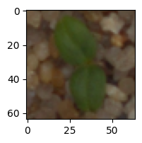

```
1/1 ━━━━━━━━━━━━━━━━━━━━ 0s 28ms/step
Predicted Label ['Charlock']
True Label Cleavers
```

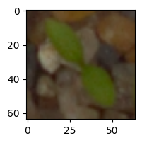

```
1/1 ━━━━━━━━━━━━━━━━━━━━ 0s 31ms/step
Predicted Label ['Common Chickweed']
True Label Common Chickweed
```

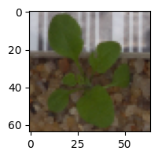

```
1/1 ━━━━━━━━━━━━━━━━━━━━ 0s 39ms/step
Predicted Label ['Charlock']
True Label Shepherds Purse
```

```python
# Visualizing the predicted and correct label of images from test data
plt.figure(figsize=(2,2))
plt.imshow(X_test[2])
plt.show()

## Predict the test data using the final model selected
print('Predicted Label', enc.inverse_transform(model2.predict((X_test_normalized[2].reshape(1,64,64,3)))))   # reshaping the input image as we are only trying to predict using a single image
print('True Label', enc.inverse_transform(y_test_encoded)[2])                                               # using inverse_transform() to get the output label from the output vector

plt.figure(figsize=(2,2))
plt.imshow(X_test[33])
plt.show()

## Predict the test data using the final model selected
print('Predicted Label', enc.inverse_transform(model2.predict((X_test_normalized[33].reshape(1,64,64,3)))))  # reshaping the input image as we are only trying to predict using a single image
print('True Label', enc.inverse_transform(y_test_encoded)[33])                                              # using inverse_transform() to get the output label from the output vector

plt.figure(figsize=(2,2))
plt.imshow(X_test[59],)
plt.show()
## Predict the test data using the final model selected
print('Predicted Label', enc.inverse_transform(model2.predict((X_test_normalized[59].reshape(1,64,64,3)))))  # reshaping the input image as we are only trying to predict using a single image
print('True Label', enc.inverse_transform(y_test_encoded)[59])                                              # using inverse_transform() to get the output label from the output vector

plt.figure(figsize=(2,2))
plt.imshow(X_test[36])
plt.show()

## Predict the test data using the final model selected
print('Predicted Label', enc.inverse_transform(model2.predict((X_test_normalized[36].reshape(1,64,64,3)))))  # reshaping the input image as we are only trying to predict using a single image
print('True Label', enc.inverse_transform(y_test_encoded)[36])                                              # using inverse_transform() to get the output label from the output vector
```

## Actionable Insights and Business Recommendations

### **Scope of Improvement**

- These models can be further improved by training with more data, different filter sizes and different number of filters.
- These models can also be trained on the original image_size i.e 128 x 128 rather than being reduced to 64.
- Data Augmentation can be performed more with different options/parameters and dropout_rate can be changed to improve the model performance.
- More attempts towards manipulatation of the dense layers with the VGG model can be tried to see if there can be further improvements using the VGG model.
- Other Transfer Learning architectures can also be used to train the CNN model and these models can be used for classification.
- Once the desired performance is achieved from the model, the company can use it to classify different images being uploaded.